# prj014: Metatranscriptomic Analysis of Bacterial Inoculation in Aiptasia

Hailey Hatch

2026-06-23

# Introduction

This notebook analyzes metatranscriptomic (RNA-seq) data from an *Aiptasia* bacterial inoculation experiment. *Aiptasia* were first treated with antibiotics to reduce their native microbiome, then inoculated with one of three bacterial symbionts to examine changes in host, algal symbiont, and bacterial gene expression.

**Treatments:**

- **control/FASW** — no antibiotics, no inoculation (natural microbiome)
- **ABS** — antibiotics only (microbiome-depleted baseline)
- **ISOA/Labrenzia** — antibiotics + *Labrenzia aggregata* inoculation
- **ISOB/Ruegeria** — antibiotics + *Ruegeria mobilis* inoculation
- **ISOC/Vibrio** — antibiotics + *Vibrio alginolyticus* inoculation
- **ISOABC/multi** — antibiotics + all three bacteria combined

**Timepoints:** 1 day post-inoculation (1dpi) and 21 days post-inoculation (21dpi)

**Replicates:** 4 biological replicates per treatment per timepoint = **48 samples total**

**Previous pipeline:** Raw reads were processed with fastp (quality trimming) → SortMeRNA (rRNA removal) → HISAT2 (alignment to a combined reference genome containing *Aiptasia* host, *Symbiodiniaceae* symbiont, *Labrenzia*, *Ruegeria*, and *Vibrio*) → featureCounts (gene-level quantification).

**Biological questions:**

1. What are the general expression patterns across treatments and timepoints?
2. How does bacterial inoculation affect host immune gene expression?
3. Are there changes in sulfur cycling genes, particularly in *Labrenzia* and *Ruegeria*?

# 1. Load Libraries & Define Constants

```r
library(readxl)
library(tidyverse)
library(DESeq2)
library(ggplot2)
library(pheatmap)
library(matrixStats)
library(ggrepel)
library(patchwork)
library(UpSetR)
```

```r
palette <- c(
  "FASW" = 'grey60',
  "ABS"     = 'black',
  "Labrenzia"    = '#A6CEE3',
  "Ruegeria"    = '#1F78B4',
  "Vibrio"    = '#B2DF8A',
  "multi"  = 'violet')
treatment_levels <- c(
  "control" = "FASW",
  "ABS" = "ABS",
  "ISOA" = "Labrenzia",
  "ISOB" = "Ruegeria",
  "ISOC" = "Vibrio",
  "ISOABC" = "multi")
```

# 2. Load All Data Files

```r
# featureCounts gene count matrix (6 annotation cols + 48 samples)
counts_raw <- read.delim("../data/counts.tsv", comment.char = "#", check.names = FALSE)

# featureCounts assignment summary
counts_summary <- read.delim("../data/counts.tsv.summary", check.names = FALSE)

# HISAT2 alignment rates
hisat2_sum <- read.delim("../data/hisat2_alignment_summary.tsv")

# Per-reference organism read counts (aip, sym, lab, rue, vib)
organism_counts <- read.delim("../data/per_reference_counts.tsv")

# SortMeRNA rRNA removal summary
sortme_sum <- read.delim("../data/sortmerna_summary.tsv")

# Fastp trimming summary
fastp_sum <- read.delim("../data/fastp_summary_per_sample.tsv", check.names = FALSE)

# Aiptasia gene annotations (SwissProt/TrEMBL BLAST, GO, KEGG)
aip_annotate <- read.delim("../data/Aiptasia_annotation_file.csv")
```

# 3. Build Sample Metadata

Create the `colData` data frame that DESeq2 requires. We’ll parse treatment and timepoint directly from the sample names so it’s fully reproducible.

```r
# Step 1: Make function to clean sample names
clean_sample_name <- function(x) {gsub("_S\\d+.*$", "", x)}

# Step 2: Get sample column names from the counts data
colnames(counts_raw) <- clean_sample_name(basename(colnames(counts_raw)))
annotation_cols <- c("Geneid", "Chr", "Start", "End", "Strand", "Length")
sample_names <- colnames(counts_raw)[!colnames(counts_raw) %in% annotation_cols]

# Step 3: Parse treatment and timepoint from the clean names
treatment <- str_extract(sample_names, "ISOABC|ISOA|ISOB|ISOC|ABS|control")
timepoint <- str_extract(sample_names, "\\d+dpi")

# Step 4: Create the colData data frame
  colData <- data.frame(row.names = sample_names, treatment = treatment, timepoint = timepoint)

# Step 5: Convert treatment and timepoint to factors with your defined levels
colData$treatment <- factor(treatment_levels[as.character(colData$treatment)],
                            levels = treatment_levels)
colData$timepoint <- factor(colData$timepoint, levels = c("1dpi", "21dpi"))

stopifnot(all(table(colData$treatment, colData$timepoint) == 4))

# Make metadata by turning rownames into a regular column
metadata <- colData %>% rownames_to_column("sample")
```

# 4. QC Summary Plots

Visualize pipeline quality metrics to identify any problematic samples before DESeq2.

## 4.1 Fastp — Read Quality & Trimming

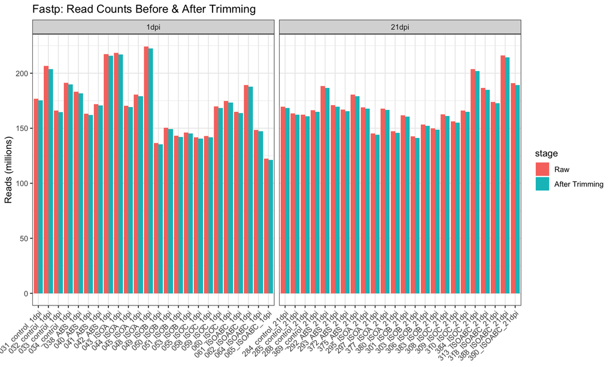

```r
plot_QC_fastp <- fastp_sum %>%
  mutate(sample = clean_sample_name(sample)) %>%
  left_join(metadata, by = "sample") %>%
  filter(!is.na(treatment)) %>%
  arrange(treatment, timepoint) %>%
  mutate(sample = fct_inorder(sample)) %>%
  select(sample, treatment, timepoint, reads_before, reads_after) %>%
  pivot_longer(cols = c(reads_before, reads_after),
               names_to = "stage", values_to = "reads") %>%
  mutate(stage = factor(stage, levels = c("reads_before", "reads_after"),
                        labels = c("Raw", "After Trimming"))) %>%
  ggplot(aes(x = sample, y = reads / 1e6, fill = stage)) +
  geom_col(position = "dodge") +
  facet_wrap(~ timepoint, scales = "free_x") +
  theme_bw() +
  theme(axis.text.x = element_text(angle = 45, hjust = 1)) +
  labs(title = "Fastp: Read Counts Before & After Trimming",
       y = "Reads (millions)", x = NULL)
plot_QC_fastp
```

```r
# No extreme trimming; all samples ~125-225M reads
```

## 4.2 SortMeRNA — rRNA Removal Rates

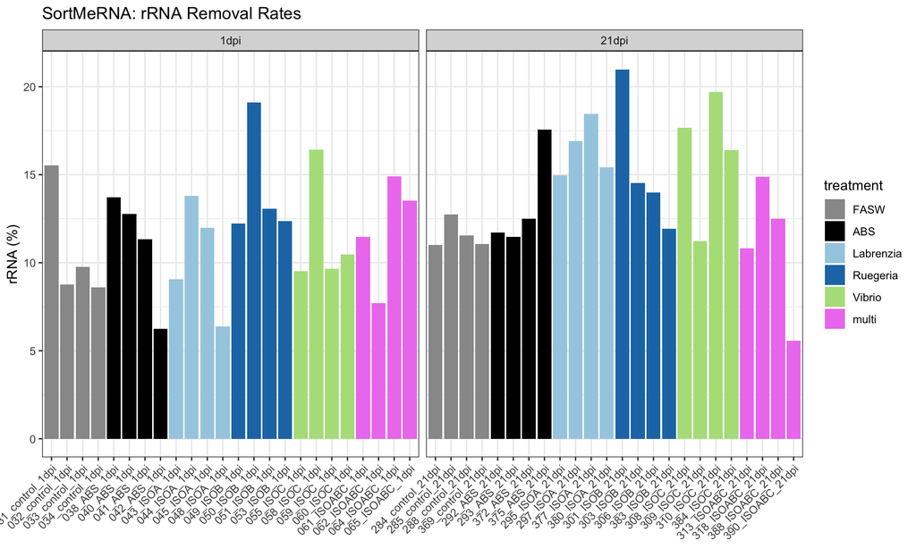

```r
plot_QC_sortmerna <- sortme_sum %>%
  mutate(sample = clean_sample_name(sample)) %>%
  left_join(metadata, by = "sample") %>%
  arrange(treatment, timepoint) %>%
  mutate(sample = fct_inorder(sample)) %>%
  ggplot(aes(x = sample, y = rRNA_pct, fill = treatment)) +
  geom_col() +
  facet_wrap(~ timepoint, scales = "free_x") +
  scale_fill_manual(values = palette) +
  theme_bw() +
  theme(axis.text.x = element_text(angle = 45, hjust = 1)) +
  labs(title = "SortMeRNA: rRNA Removal Rates", y = "rRNA (%)", x = NULL)
plot_QC_sortmerna
```

```r
# ~5-20% rRNA; 21dpi slightly higher on average
```

## 4.3 HISAT2 — Alignment Rates

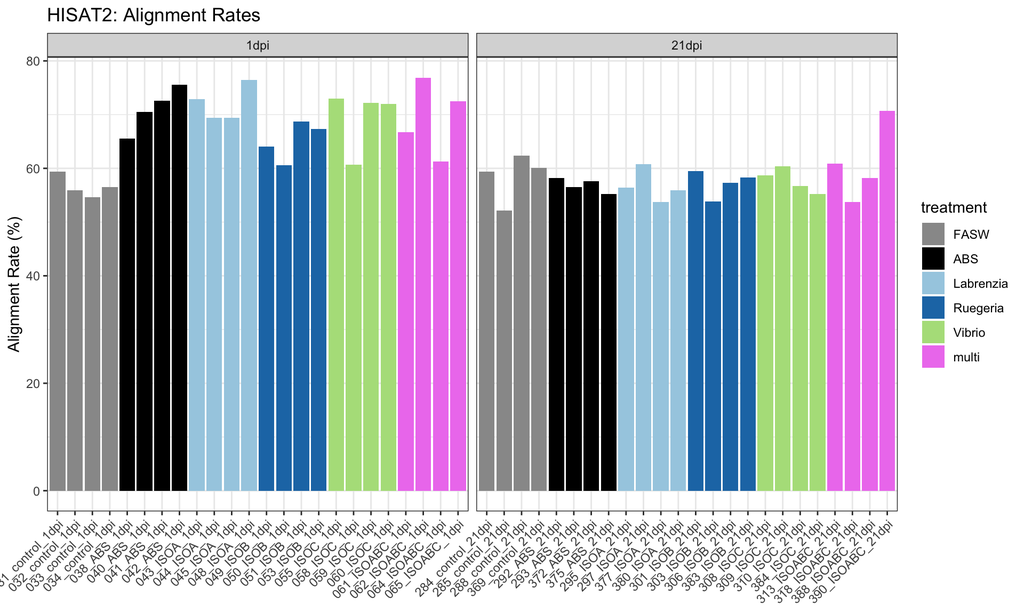

```r
plot_QC_hisat2 <- hisat2_sum %>%
  mutate(sample = clean_sample_name(sample)) %>%
  left_join(metadata, by = "sample") %>%
  arrange(treatment, timepoint) %>%
  mutate(sample = fct_inorder(sample)) %>%
  ggplot(aes(x = sample, y = `overall_alignment_rate...`, fill = treatment)) +
  geom_col() +
  facet_wrap(~ timepoint, scales = "free_x") +
  scale_fill_manual(values = palette) +
  theme_bw() +
  theme(axis.text.x = element_text(angle = 45, hjust = 1)) +
  labs(title = "HISAT2: Alignment Rates", y = "Alignment Rate (%)", x = NULL)
plot_QC_hisat2
```

```r
# Alignment rates 50-75%
```

## 4.4 Supplementary Fig S1 — % Library Mapped to Each Genome

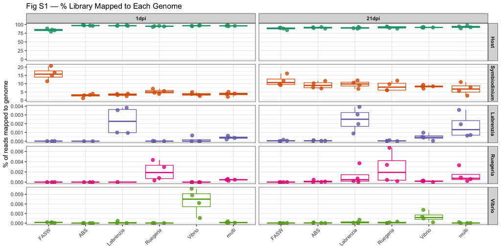

```r
# Compute % of total mapped reads assigned to each organism per sample
figS1_data <- organism_counts %>%
  mutate(sample = clean_sample_name(sample)) %>%
  left_join(metadata, by = "sample") %>%
  mutate(total = aip + sym + lab + rue + vib) %>%
  pivot_longer(cols = c(aip, sym, lab, rue, vib),
               names_to = "organism", values_to = "reads") %>%
  mutate(pct_mapped = 100 * reads / total,
         organism = factor(organism,
                           levels = c("aip", "sym", "lab", "rue", "vib"),
                           labels = c("Host", "Symbiodinium", "Labrenzia", "Ruegeria", "Vibrio")),
         treatment = factor(treatment, levels = treatment_levels))

plot_figS1 <- ggplot(figS1_data, aes(x = treatment, y = pct_mapped, color = organism)) +
  geom_boxplot(outlier.shape = NA, alpha = 0.7) +
  geom_jitter(width = 0.2, size = 2.5, alpha = 0.8) +
  facet_grid(organism ~ timepoint, scales = "free_y") +
  scale_color_manual(values = c("Host" = "#1b9e77", "Symbiodinium" = "#d95f02",
                                "Labrenzia" = "#7570b3", "Ruegeria" = "#e7298a",
                                "Vibrio" = "#66a61e")) +
  ylim(0, NA) +
  theme_bw() +
  theme(axis.text.x = element_text(angle = 45, hjust = 1),
        legend.position = "none",
        strip.text = element_text(face = "bold")) +
  labs(title = "Fig S1 — % Library Mapped to Each Genome",
       y = "% of reads mapped to genome", x = NULL)
plot_figS1
```

```r
ggsave("../results/FigS1_pct_mapped_by_genome.pdf", plot_figS1, width = 12, height = 6)
ggsave("../results/FigS1_pct_mapped_by_genome.png", plot_figS1, width = 12, height = 6, dpi = 300)
```

## 4.5 featureCounts — Read Assignment Summary

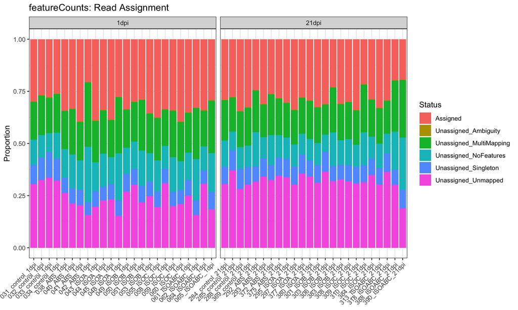

```r
colnames(counts_summary) <- clean_sample_name(basename(colnames(counts_summary)))

fc_data <- counts_summary %>%
  pivot_longer(cols = -Status, names_to = "sample", values_to = "reads") %>%
  filter(reads > 0) %>%
  left_join(metadata, by = "sample") %>%
  arrange(treatment, timepoint) %>%
  mutate(sample = fct_inorder(sample))

plot_QC_featurecounts <- ggplot(fc_data, aes(x = sample, y = reads, fill = Status)) +
  geom_col(position = "fill") +
  facet_wrap(~ timepoint, scales = "free_x") +
  theme_bw() +
  theme(axis.text.x = element_text(angle = 45, hjust = 1)) +
  labs(title = "featureCounts: Read Assignment", y = "Proportion", x = NULL)
plot_QC_featurecounts
```

```r
# Assigned reads ~25% — low but expected for metatranscriptomic reference
```

## 4.6 featureCounts — Library Size

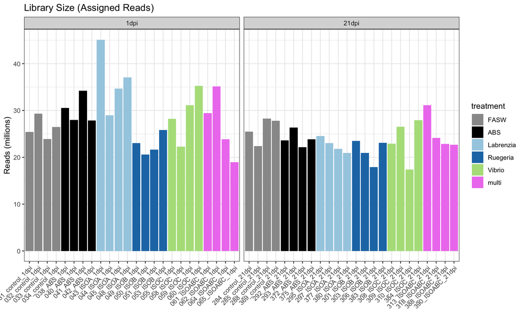

```r
plot_QC_library_size <- fc_data %>%
  filter(Status == "Assigned") %>%
  ggplot(aes(x = sample, y = reads / 1e6, fill = treatment)) +
  geom_col() +
  facet_wrap(~ timepoint, scales = "free_x") +
  scale_fill_manual(values = palette) +
  theme_bw() +
  theme(axis.text.x = element_text(angle = 45, hjust = 1)) +
  labs(title = "Library Size (Assigned Reads)", y = "Reads (millions)", x = NULL)
plot_QC_library_size
```

```r
# ~20-40M reads assigned to combined reference per sample
```

## 4.7 Save QC Plots

```r
qc_plots <- list(
  "plot_QC_fastp"         = plot_QC_fastp,
  "plot_QC_sortmerna"     = plot_QC_sortmerna,
  "plot_QC_hisat2"        = plot_QC_hisat2,
  "plot_QC_featurecounts" = plot_QC_featurecounts,
  "plot_QC_library_size"  = plot_QC_library_size)

for (name in names(qc_plots)) {
  ggsave(paste0("../results/", name, ".pdf"), qc_plots[[name]], width = 10, height = 6)
  ggsave(paste0("../results/", name, ".png"), qc_plots[[name]], width = 10, height = 6, dpi = 300)
}
```

# 5. Clean and Prepare the Count Matrix

Transform the raw featureCounts output into a clean integer count matrix that DESeq2 can use.

```r
# Save gene lengths for TPM calculation later
gene_lengths <- counts_raw %>% select(Geneid, Length) %>% column_to_rownames("Geneid")

counts_matrix <- counts_raw %>%
  select(-Chr, -Start, -End, -Strand, -Length) %>%
  column_to_rownames("Geneid") %>%
  as.matrix()
counts_matrix <- round(counts_matrix)

all(colnames(counts_matrix) == rownames(colData))
```

```
## [1] TRUE
```

```r
dim(counts_matrix)
```

```
## [1] 89805    48
```

## 5.1 Compute TPM Matrix

TPM (Transcripts Per Million) normalizes for both gene length and sequencing depth, making expression values comparable across samples AND genes

TPM formula: for each gene in each sample, 1. Divide raw count by gene length in kb → RPK (reads per kilobase) 2. Sum all RPKs in that sample → scaling factor 3. Divide each RPK by (scaling factor / 1e6) → TPM

```r
all(rownames(gene_lengths) == rownames(counts_matrix))
```

```
## [1] TRUE
```

```r
gene_lengths_kb <- gene_lengths$Length / 1000

rpk_matrix <- sweep(counts_matrix, 1, gene_lengths_kb, "/")

scaling_factors <- colSums(rpk_matrix)

tpm_matrix <- sweep(rpk_matrix, 2, scaling_factors / 1e6, "/")

tpm_aip <- tpm_matrix[startsWith(rownames(tpm_matrix), "aip_"), ]
tpm_sym <- tpm_matrix[startsWith(rownames(tpm_matrix), "sym_"), ]
tpm_lab <- tpm_matrix[startsWith(rownames(tpm_matrix), "lab_"), ]
tpm_rue <- tpm_matrix[startsWith(rownames(tpm_matrix), "rue_"), ]
tpm_vib <- tpm_matrix[startsWith(rownames(tpm_matrix), "vib_"), ]
```

# 6. Split Counts by Organism

Analyzing organisms separately because: - Library size normalization should be computed within an organism - The biological questions differ per organism - Read depths vary (host: millions, bacteria: thousands)

```r
counts_aip <- counts_matrix[startsWith(rownames(counts_matrix), "aip_"), ]
counts_sym <- counts_matrix[startsWith(rownames(counts_matrix), "sym_"), ]
counts_lab <- counts_matrix[startsWith(rownames(counts_matrix), "lab_"), ]
counts_rue <- counts_matrix[startsWith(rownames(counts_matrix), "rue_"), ]
counts_vib <- counts_matrix[startsWith(rownames(counts_matrix), "vib_"), ]

# Verify splits include all counts
nrow(counts_aip) + nrow(counts_sym) + nrow(counts_lab) + nrow(counts_rue) + nrow(counts_vib) == nrow(counts_matrix)
```

```
## [1] TRUE
```

```r
organism_list <- list(
  aip = counts_aip, sym = counts_sym,
  lab = counts_lab, rue = counts_rue, vib = counts_vib)

organism_summary <- data.frame(
  organism = names(organism_list),
  total_genes = sapply(organism_list, nrow),
  median_counts_per_sample = sapply(organism_list, function(x) median(colSums(x))),
  genes_all_zero = sapply(organism_list, function(x) sum(rowSums(x) == 0)),
  genes_passing_filter = sapply(organism_list, function(x) sum(rowSums(x >= 10) >= 4))
)
organism_summary
```

```
##     organism total_genes median_counts_per_sample genes_all_zero
## aip      aip       30953               23952479.0            332
## sym      sym       43403                 472279.5          16329
## lab      lab        5920                     15.5           2717
## rue      rue        4669                     17.0           2801
## vib      vib        4860                      4.0           2527
##     genes_passing_filter
## aip                29680
## sym                12921
## lab                    0
## rue                    3
## vib                   19
```

```r
# Few bacterial genes passed the filter
```

```r
for (name in names(organism_list)) {
  write.table(organism_list[[name]],
              file = paste0("../results/counts_", name, ".tsv"),
              sep = "\t", quote = FALSE, col.names = NA)}
```

# 7. Prepare Annotation Data

The annotation file has multiple transcript isoforms per gene (e.g., g1.t1 and g1.t2 are isoforms of gene g1). We need to:

1. Extract the gene-level ID
2. Match it to the count matrix format (with `aip_` prefix)
3. Deduplicate to one annotation per gene

```r
# Step 1: Extract gene ID from Protein_ID
aip_annotate <- aip_annotate %>%
  mutate(gene_id = paste0("aip_", sub("\\..*$", "", Protein_ID)))

# Step 2: Extract a short protein name from the SwissProt BLAST hit column
aip_annotate <- aip_annotate %>%
  mutate(protein_name = str_extract(`BLAST_hit..SwissProt.`, "(?<=\\|)[^|]+(?=_)"))

# Step 3: Deduplicate — keep one row per gene_id
aip_annotate <- aip_annotate %>%
  group_by(gene_id) %>%
  slice_min(`E.value..SwissProt.`, n = 1, with_ties = FALSE, na_rm = TRUE) %>%
  ungroup()

# Step 4: Select key columns for the final annotation table: gene_id, protein_name, BLAST description, GO terms, KEGG_ID
aip_annotate <- aip_annotate %>%
  select(gene_id, protein_name, Protein_ID,
         starts_with("Hit_description"),
         starts_with("GO_"),
         KEGG_ID)
```

## 7.2 Parse Bacterial Annotations from GFF3

The three bacterial genomes were annotated with [Bakta](https://github.com/oschwengers/bakta). The GFF3 files contain rich `Name=` (product), `gene=`, `KEGG:`, and `COG:` fields in the attributes column. We parse CDS features to build annotation tables matching the count matrix gene IDs (`lab_AODPDA_XXXXX`, `rue_LDIBIJ_XXXXX`, `vib_BPEJFA_XXXXX`).

```r
parse_bakta_gff3 <- function(gff3_path, prefix) {
  lines <- readLines(gff3_path)
  lines <- lines[!grepl("^#", lines) & nchar(lines) > 0]

  gff <- read.delim(textConnection(lines), header = FALSE,
                    col.names = c("seqid","source","type","start","end",
                                  "score","strand","phase","attributes"))

  gff_cds <- gff %>% filter(type == "CDS")

  gff_cds <- gff_cds %>%
    mutate(
      locus_tag  = str_extract(attributes, "(?<=locus_tag=)[^;]+"),
      gene_name  = str_extract(attributes, "(?<=;gene=|^gene=)[^;]+"),
      product    = str_extract(attributes, "(?<=Name=)[^;]+") %>% URLdecode(),
      kegg       = str_extract(attributes, "(?<=KEGG:)[^,;]+"),
      cog_id     = str_extract(attributes, "(?<=COG:COG)\\d+") %>%
                     {ifelse(is.na(.), NA, paste0("COG", .))},
      go_terms   = str_extract(attributes, "(?<=Dbxref=).*") %>%
                     str_extract_all("GO:\\d+") %>%
                     sapply(function(x) paste(x, collapse = ";"))
    ) %>%
    mutate(
      gene_id = paste0(prefix, "_", locus_tag),
      go_terms = ifelse(go_terms == "", NA, go_terms)
    ) %>%
    select(gene_id, locus_tag, gene_name, product, kegg, cog_id, go_terms) %>%
    distinct(gene_id, .keep_all = TRUE)

  return(gff_cds)
}

annot_lab <- parse_bakta_gff3("../data/labrenzia.gff3", "lab")
annot_rue <- parse_bakta_gff3("../data/ruegeria.gff3",  "rue")
annot_vib <- parse_bakta_gff3("../data/vibrio.gff3",    "vib")

annot_bact <- bind_rows(
  annot_lab %>% mutate(organism = "Labrenzia"),
  annot_rue %>% mutate(organism = "Ruegeria"),
  annot_vib %>% mutate(organism = "Vibrio")
)

cat("Labrenzia:", nrow(annot_lab), "CDS,", sum(!is.na(annot_lab$gene_name)), "with gene names,",
    sum(!is.na(annot_lab$kegg)), "with KEGG\n")
```

```
## Labrenzia: 5844 CDS, 4103 with gene names, 1019 with KEGG
```

```r
cat("Ruegeria:", nrow(annot_rue), "CDS,", sum(!is.na(annot_rue$gene_name)), "with gene names,",
    sum(!is.na(annot_rue$kegg)), "with KEGG\n")
```

```
## Ruegeria: 4587 CDS, 3014 with gene names, 730 with KEGG
```

```r
cat("Vibrio:", nrow(annot_vib), "CDS,", sum(!is.na(annot_vib$gene_name)), "with gene names,",
    sum(!is.na(annot_vib$kegg)), "with KEGG\n")
```

```
## Vibrio: 4666 CDS, 2545 with gene names, 796 with KEGG
```

## 7.3 Parse Symbiont Annotations from Combined GTF

The *Symbiodiniaceae* genes in the combined GTF have `gene` and `product` attributes on transcript lines. We extract one annotation per gene_id.

```r
gtf_lines <- readLines("../data/combined_annotation.gtf")
sym_transcript_lines <- gtf_lines[grepl("^sym_", gtf_lines) & grepl("\\ttranscript\\t", gtf_lines)]

annot_sym <- data.frame(raw = sym_transcript_lines, stringsAsFactors = FALSE) %>%
  mutate(
    gene_id   = str_extract(raw, 'gene_id "([^"]+)"', group = 1),
    gene_name = str_extract(raw, 'gene "([^"]+)"', group = 1),
    product   = str_extract(raw, 'product "([^"]+)"', group = 1)
  ) %>%
  select(-raw) %>%
  filter(!is.na(gene_id)) %>%
  distinct(gene_id, .keep_all = TRUE)

# Create a label column: prefer gene_name, then non-hypothetical product, then gene_id
annot_sym <- annot_sym %>%
  mutate(label = case_when(
    !is.na(gene_name) ~ gene_name,
    !is.na(product) & product != "hypothetical protein" ~ str_trunc(product, 40),
    TRUE ~ gene_id
  ))

cat("Symbiont:", nrow(annot_sym), "genes,",
    sum(!is.na(annot_sym$gene_name)), "with gene names,",
    sum(!is.na(annot_sym$product) & annot_sym$product != "hypothetical protein"),
    "with non-hypothetical products\n")
```

```
## Symbiont: 43403 genes, 12195 with gene names, 14763 with non-hypothetical products
```

# 8. DESeq2 Analysis — Host (*Aiptasia*)

Host differential expression analysis using DESeq2. DESeq2 models RNA-seq count data using a negative binomial distribution, accounts for library size differences between samples, and uses shrinkage to produce more reliable fold-change estimates.

## 8.1 Create DESeq Object and Filter Low-Count Genes

```r
dds_aip <- DESeqDataSetFromMatrix(
  countData = counts_aip,
  colData = colData,
  design = ~ timepoint + treatment)

cat(nrow(dds_aip), "genes before filtering\n")
```

```
## 30953 genes before filtering
```

```r
keep <- rowSums(counts(dds_aip) >= 10) >= 4
dds_aip <- dds_aip[keep, ]
cat(nrow(dds_aip), "genes after filtering\n")
```

```
## 29680 genes after filtering
```

```r
#removes genes that don't have at least 10 counts in at least 4 samples
```

## 8.2 Run DESeq2

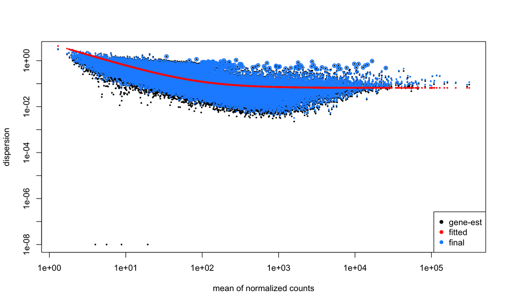

```r
dds_aip <- DESeq(dds_aip)
plotDispEsts(dds_aip)
```

```r
# Dispersion plot looks good: trend line decreases smoothly, gene-wise estimates converge (black dots)
```

## 8.3 Exploratory Plots

### VST Transformation

```r
vsd_aip <- vst(dds_aip, blind = TRUE)
```

### PCA — All Samples

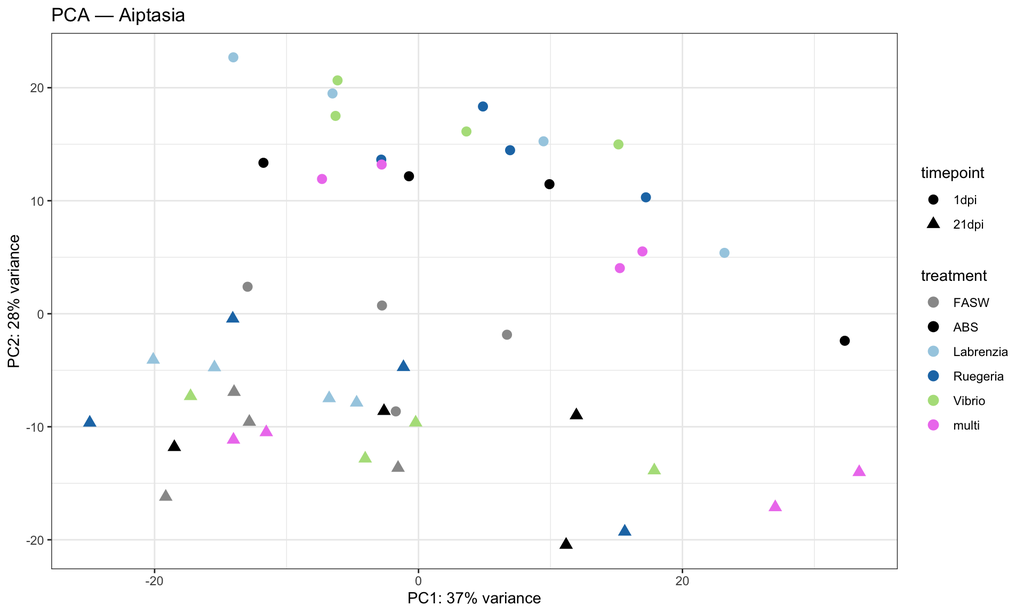

```r
pca_data <- plotPCA(vsd_aip, intgroup = c("treatment", "timepoint"), returnData = TRUE)
percent_var <- round(100 * attr(pca_data, "percentVar"))

p <- ggplot(pca_data, aes(x = PC1, y = PC2, color = treatment, shape = timepoint)) +
  geom_point(size = 3) +
  scale_color_manual(values = palette) +
  theme_bw() +
  labs(x = paste0("PC1: ", percent_var[1], "% variance"),
       y = paste0("PC2: ", percent_var[2], "% variance"),
       title = "PCA — Aiptasia")
p
```

```r
ggsave("../results/pca_host_all.pdf", p, width = 7, height = 5)
# Timepoint is the dominant source of variation, although controls at 1dpi cluster with all 21dpi, suggesting variation largely due to ABS influence
```

### PCA — Per Timepoint

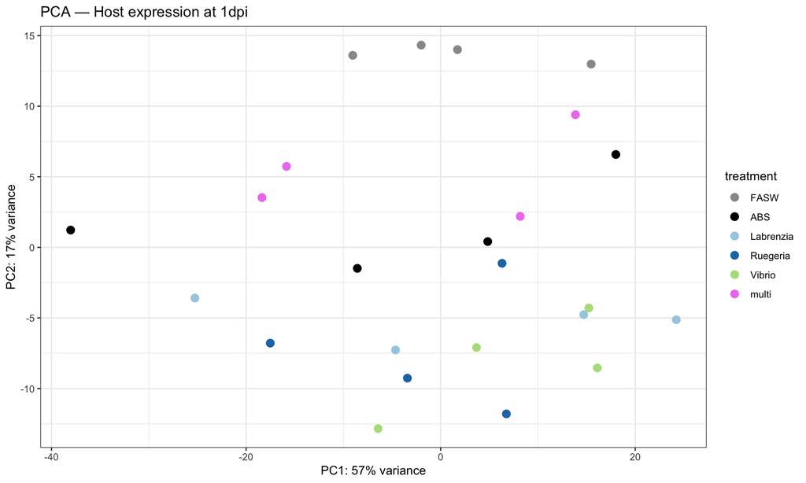

```r
vsd_aip_1dpi <- vsd_aip[, vsd_aip$timepoint == "1dpi"]

pca_data <- plotPCA(vsd_aip_1dpi, intgroup = c("treatment"), returnData = TRUE)
percent_var <- round(100 * attr(pca_data, "percentVar"))

p <- ggplot(pca_data, aes(x = PC1, y = PC2, color = treatment)) +
  geom_point(size = 3) +
  scale_color_manual(values = palette) +
  theme_bw() +
  labs(x = paste0("PC1: ", percent_var[1], "% variance"),
       y = paste0("PC2: ", percent_var[2], "% variance"),
       title = "PCA — Host expression at 1dpi")
p
```

```r
ggsave("../results/pca_host_1dpi.pdf", p, width = 6, height = 5)
# Control separates from all others — antibiotic effect dominates at 1dpi
```

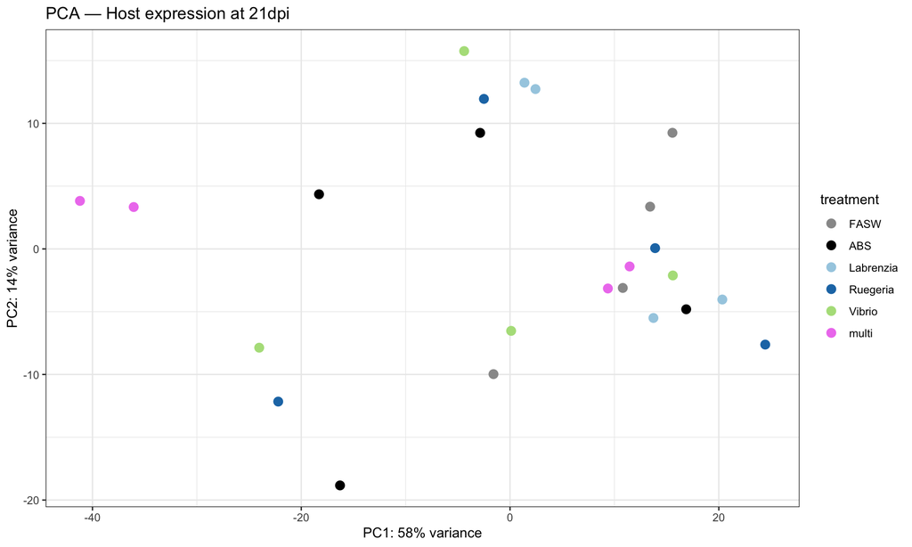

```r
vsd_aip_21dpi <- vsd_aip[, vsd_aip$timepoint == "21dpi"]

pca_data <- plotPCA(vsd_aip_21dpi, intgroup = c("treatment"), returnData = TRUE)
percent_var <- round(100 * attr(pca_data, "percentVar"))

p <- ggplot(pca_data, aes(x = PC1, y = PC2, color = treatment)) +
  geom_point(size = 3) +
  scale_color_manual(values = palette) +
  theme_bw() +
  labs(x = paste0("PC1: ", percent_var[1], "% variance"),
       y = paste0("PC2: ", percent_var[2], "% variance"),
       title = "PCA — Host expression at 21dpi")
p
```

```r
ggsave("../results/pca_host_21dpi.pdf", p, width = 6, height = 5)
# More dispersed at 21dpi — increased variability over time
```

## 8.4 Differential Expression by Timepoint

ABS is the reference because bacteria were inoculated into antibiotic knocked down animals so the fair comparison is each inoculum versus the antibiotic baseline.

### 1dpi Contrasts

```r
dds_aip_1dpi <- dds_aip[, dds_aip$timepoint == "1dpi"]
dds_aip_1dpi$timepoint <- droplevels(dds_aip_1dpi$timepoint)
design(dds_aip_1dpi) <- ~ treatment
dds_aip_1dpi <- DESeq(dds_aip_1dpi)

# contrasts of all treatments in comparison to ABS
res_aip_1dpi_control <- results(dds_aip_1dpi, contrast = c("treatment", "FASW", "ABS"))
res_aip_1dpi_ISOA <- results(dds_aip_1dpi, contrast = c("treatment", "Labrenzia", "ABS"))
res_aip_1dpi_ISOB <- results(dds_aip_1dpi, contrast = c("treatment", "Ruegeria", "ABS"))
res_aip_1dpi_ISOC <- results(dds_aip_1dpi, contrast = c("treatment", "Vibrio", "ABS"))
res_aip_1dpi_ISOABC <- results(dds_aip_1dpi, contrast = c("treatment", "multi", "ABS"))

# Figure 5 contrasts: single isolate vs community (of host genes)
res_aip_1dpi_ISOA_vs_ISOABC <- results(dds_aip_1dpi, contrast = c("treatment", "Labrenzia", "multi"))
res_aip_1dpi_ISOB_vs_ISOABC <- results(dds_aip_1dpi, contrast = c("treatment", "Ruegeria", "multi"))
res_aip_1dpi_ISOC_vs_ISOABC <- results(dds_aip_1dpi, contrast = c("treatment", "Vibrio", "multi"))
```

### 21dpi Contrasts

```r
dds_aip_21dpi <- dds_aip[, dds_aip$timepoint == "21dpi"]
dds_aip_21dpi$timepoint <- droplevels(dds_aip_21dpi$timepoint)
design(dds_aip_21dpi) <- ~ treatment
dds_aip_21dpi <- DESeq(dds_aip_21dpi)

# contrasts of all treatments in comparison to ABS
res_aip_21dpi_control <- results(dds_aip_21dpi, contrast = c("treatment", "FASW", "ABS"))
res_aip_21dpi_ISOA <- results(dds_aip_21dpi, contrast = c("treatment", "Labrenzia", "ABS"))
res_aip_21dpi_ISOB <- results(dds_aip_21dpi, contrast = c("treatment", "Ruegeria", "ABS"))
res_aip_21dpi_ISOC <- results(dds_aip_21dpi, contrast = c("treatment", "Vibrio", "ABS"))
res_aip_21dpi_ISOABC <- results(dds_aip_21dpi, contrast = c("treatment", "multi", "ABS"))

# Figure 5 contrasts: single isolate vs community (of host genes)
res_aip_21dpi_ISOA_vs_ISOABC <- results(dds_aip_21dpi, contrast = c("treatment", "Labrenzia", "multi"))
res_aip_21dpi_ISOB_vs_ISOABC <- results(dds_aip_21dpi, contrast = c("treatment", "Ruegeria", "multi"))
res_aip_21dpi_ISOC_vs_ISOABC <- results(dds_aip_21dpi, contrast = c("treatment", "Vibrio", "multi"))
```

### DEG Summary Table

```r
summarize_degs <- function(res) {
  df <- as.data.frame(res)
  up <- sum(df$padj < 0.05 & df$log2FoldChange > 0, na.rm = TRUE)
  down <- sum(df$padj < 0.05 & df$log2FoldChange < 0, na.rm = TRUE)
  data.frame(up = up, down = down, total = up + down)
  }
deg_summary_aip <- bind_rows(
  summarize_degs(res_aip_1dpi_control) %>% mutate(timepoint = "1dpi", contrast = "FASW_vs_ABS"),
  summarize_degs(res_aip_1dpi_ISOA) %>% mutate(timepoint = "1dpi", contrast = "Labrenzia_vs_ABS"),
  summarize_degs(res_aip_1dpi_ISOB) %>% mutate(timepoint = "1dpi", contrast = "Ruegeria_vs_ABS"),
  summarize_degs(res_aip_1dpi_ISOC) %>% mutate(timepoint = "1dpi", contrast = "Vibrio_vs_ABS"),
  summarize_degs(res_aip_1dpi_ISOABC) %>% mutate(timepoint = "1dpi", contrast = "multi_vs_ABS"),
  summarize_degs(res_aip_21dpi_control) %>% mutate(timepoint = "21dpi", contrast = "FASW_vs_ABS"),
  summarize_degs(res_aip_21dpi_ISOA) %>% mutate(timepoint = "21dpi", contrast = "Labrenzia_vs_ABS"),
  summarize_degs(res_aip_21dpi_ISOB) %>% mutate(timepoint = "21dpi", contrast = "Ruegeria_vs_ABS"),
  summarize_degs(res_aip_21dpi_ISOC) %>% mutate(timepoint = "21dpi", contrast = "Vibrio_vs_ABS"),
  summarize_degs(res_aip_21dpi_ISOABC) %>% mutate(timepoint = "21dpi", contrast = "multi_vs_ABS")
)

deg_summary_aip <- deg_summary_aip %>% select(timepoint, contrast, up, down, total)
deg_summary_aip
```

```
##    timepoint         contrast  up down total
## 1       1dpi      FASW_vs_ABS 353  295   648
## 2       1dpi Labrenzia_vs_ABS   1    7     8
## 3       1dpi  Ruegeria_vs_ABS   4   21    25
## 4       1dpi    Vibrio_vs_ABS  31   39    70
## 5       1dpi     multi_vs_ABS   0    3     3
## 6      21dpi      FASW_vs_ABS 225  745   970
## 7      21dpi Labrenzia_vs_ABS   0    0     0
## 8      21dpi  Ruegeria_vs_ABS   0    2     2
## 9      21dpi    Vibrio_vs_ABS   0    5     5
## 10     21dpi     multi_vs_ABS   1    0     1
```

```r
# Bacterial influence on host expression is acute (stronger at 1dpi and fades by 21dpi). ABS treatment creates a huge host response, both up and down regulating genes.
```

## Annotate and Export DEG Tables

```r
export_degs <- function(res, annotation, filename) {
  df <- as.data.frame(res) %>%
    rownames_to_column("gene_id")

  df_sig <- df %>%
    filter(padj < 0.05)

  df_annotated <- df_sig %>%
    left_join(annotation, by = "gene_id")

  df_annotated <- df_annotated %>%
    arrange(padj)

  write.csv(df_annotated, file = filename, row.names = FALSE)

  return(df_annotated)
}

deg_aip_1dpi_control <- export_degs(res_aip_1dpi_control, aip_annotate, "../results/DEG_1dpi_control_vs_ABS.csv")
deg_aip_1dpi_ISOA    <- export_degs(res_aip_1dpi_ISOA, aip_annotate, "../results/DEG_1dpi_ISOA_vs_ABS.csv")
deg_aip_1dpi_ISOB    <- export_degs(res_aip_1dpi_ISOB, aip_annotate, "../results/DEG_1dpi_ISOB_vs_ABS.csv")
deg_aip_1dpi_ISOC    <- export_degs(res_aip_1dpi_ISOC, aip_annotate, "../results/DEG_1dpi_ISOC_vs_ABS.csv")
deg_aip_1dpi_ISOABC  <- export_degs(res_aip_1dpi_ISOABC, aip_annotate, "../results/DEG_1dpi_ISOABC_vs_ABS.csv")

deg_aip_21dpi_control <- export_degs(res_aip_21dpi_control, aip_annotate, "../results/DEG_21dpi_control_vs_ABS.csv")
deg_aip_21dpi_ISOA    <- export_degs(res_aip_21dpi_ISOA, aip_annotate, "../results/DEG_21dpi_ISOA_vs_ABS.csv")
deg_aip_21dpi_ISOB    <- export_degs(res_aip_21dpi_ISOB, aip_annotate, "../results/DEG_21dpi_ISOB_vs_ABS.csv")
deg_aip_21dpi_ISOC    <- export_degs(res_aip_21dpi_ISOC, aip_annotate, "../results/DEG_21dpi_ISOC_vs_ABS.csv")
deg_aip_21dpi_ISOABC  <- export_degs(res_aip_21dpi_ISOABC, aip_annotate, "../results/DEG_21dpi_ISOABC_vs_ABS.csv")

saveRDS(dds_aip, "../results/dds_aip.rds")
saveRDS(dds_aip_1dpi, "../results/dds_aip_1dpi.rds")
saveRDS(dds_aip_21dpi, "../results/dds_aip_21dpi.rds")
```

## 8.5 Differential Expression by Timepoint Within Treatment

Compare 21dpi vs 1dpi within each treatment to identify genes whose expression changes over time in each treatment context. Positive log2FC = upregulated at 21dpi relative to 1dpi.

```r
run_timepoint_deseq <- function(treatment_name, counts, coldata) {
  samps <- rownames(coldata)[coldata$treatment == treatment_name]
  mat <- counts[, samps]
  cd <- coldata[samps, , drop = FALSE]
  cd$timepoint <- droplevels(cd$timepoint)
  dds <- DESeqDataSetFromMatrix(countData = mat, colData = cd, design = ~ timepoint)
  keep <- rowSums(counts(dds) >= 10) >= 2
  dds <- dds[keep, ]
  dds <- DESeq(dds)
  results(dds, contrast = c("timepoint", "21dpi", "1dpi"))
}

res_time_FASW  <- run_timepoint_deseq("FASW",      counts_aip, colData)
res_time_ABS   <- run_timepoint_deseq("ABS",       counts_aip, colData)
res_time_Lab   <- run_timepoint_deseq("Labrenzia",  counts_aip, colData)
res_time_Rue   <- run_timepoint_deseq("Ruegeria",   counts_aip, colData)
res_time_Vib   <- run_timepoint_deseq("Vibrio",     counts_aip, colData)
res_time_multi <- run_timepoint_deseq("multi",      counts_aip, colData)

timepoint_contrasts <- list(
  FASW      = res_time_FASW,
  ABS       = res_time_ABS,
  Labrenzia = res_time_Lab,
  Ruegeria  = res_time_Rue,
  Vibrio    = res_time_Vib,
  multi     = res_time_multi
)

deg_summary_timepoint <- map_dfr(names(timepoint_contrasts), function(trt) {
  summarize_degs(timepoint_contrasts[[trt]]) %>%
    mutate(treatment = trt, contrast = "21dpi_vs_1dpi")
}) %>% select(treatment, contrast, up, down, total)

deg_summary_timepoint
```

```
##   treatment      contrast   up down total
## 1      FASW 21dpi_vs_1dpi  809  333  1142
## 2       ABS 21dpi_vs_1dpi  213  204   417
## 3 Labrenzia 21dpi_vs_1dpi 1435  807  2242
## 4  Ruegeria 21dpi_vs_1dpi  767  432  1199
## 5    Vibrio 21dpi_vs_1dpi  649 1201  1850
## 6     multi 21dpi_vs_1dpi  103  275   378
```

```r
# Positive = upregulated at 21dpi; treatment-specific temporal trajectories
```

```r
for (trt in names(timepoint_contrasts)) {
  export_degs(timepoint_contrasts[[trt]], aip_annotate,
              paste0("../results/DEG_timepoint_21vs1dpi_", trt, ".csv"))
}
```

## 8.6 Volcano Plot Helper + Downregulated Gene Lists

### Volcano Plot Helper Function

```r
plot_volcano <- function(res, annotation, title) {
  df <- as.data.frame(res) %>%
    rownames_to_column("gene_id") %>%
    left_join(annotation, by = "gene_id") %>%
    mutate(sig = case_when(
      padj < 0.05 & log2FoldChange > 1  ~ "Up",
      padj < 0.05 & log2FoldChange < -1 ~ "Down",
      TRUE ~ "NS"))

  top_genes <- df %>% filter(sig != "NS") %>%
    slice_min(padj, n = 10, with_ties = FALSE)

  ggplot(df, aes(x = log2FoldChange, y = -log10(padj), color = sig)) +
    geom_point(alpha = 0.4, size = 1) +
    scale_color_manual(values = c("Up" = "red", "Down" = "blue", "NS" = "gray70")) +
    geom_text_repel(data = top_genes, aes(label = protein_name),
                    size = 3, max.overlaps = 15) +
    geom_hline(yintercept = -log10(0.05), linetype = "dashed", color = "gray40") +
    geom_vline(xintercept = c(-1, 1), linetype = "dashed", color = "gray40") +
    theme_bw() +
    labs(title = title, x = "log2 Fold Change", y = "-log10(adjusted p-value)")
}
```

### Downregulated Gene Lists

Extract downregulated DEGs from each host contrast (padj<0.05, log2FC<-1), annotate with descriptions and GO/KEGG to see what functional categories are being suppressed.

```r
all_host_contrasts_vol <- list(
  "1dpi_FASW_vs_ABS"       = res_aip_1dpi_control,
  "1dpi_Labrenzia_vs_ABS"  = res_aip_1dpi_ISOA,
  "1dpi_Ruegeria_vs_ABS"   = res_aip_1dpi_ISOB,
  "1dpi_Vibrio_vs_ABS"     = res_aip_1dpi_ISOC,
  "1dpi_multi_vs_ABS"      = res_aip_1dpi_ISOABC,
  "21dpi_FASW_vs_ABS"      = res_aip_21dpi_control,
  "21dpi_Labrenzia_vs_ABS" = res_aip_21dpi_ISOA,
  "21dpi_Ruegeria_vs_ABS"  = res_aip_21dpi_ISOB,
  "21dpi_Vibrio_vs_ABS"    = res_aip_21dpi_ISOC,
  "21dpi_multi_vs_ABS"     = res_aip_21dpi_ISOABC
)

down_genes_all <- map_dfr(names(all_host_contrasts_vol), function(cn) {
  res <- all_host_contrasts_vol[[cn]]
  as.data.frame(res) %>%
    rownames_to_column("gene_id") %>%
    filter(!is.na(padj), padj < 0.05, log2FoldChange < -1) %>%
    arrange(log2FoldChange) %>%
    left_join(aip_annotate %>%
                select(gene_id, protein_name,
                       any_of(c("Hit_description..SwissProt.",
                                "Hit_description..TrEMBL.",
                                "KEGG_ID")),
                       starts_with("GO_IDs")),
              by = "gene_id") %>%
    mutate(contrast = cn) %>%
    select(contrast, gene_id, protein_name, log2FoldChange, padj, everything())
})

down_genes_all %>% dplyr::count(contrast, name = "n_downregulated") %>% print()
```

```
##                contrast n_downregulated
## 1      1dpi_FASW_vs_ABS              79
## 2 1dpi_Labrenzia_vs_ABS               6
## 3  1dpi_Ruegeria_vs_ABS              18
## 4    1dpi_Vibrio_vs_ABS              21
## 5     1dpi_multi_vs_ABS               1
## 6     21dpi_FASW_vs_ABS             589
## 7 21dpi_Ruegeria_vs_ABS               2
## 8   21dpi_Vibrio_vs_ABS               5
```

```r
write_csv(down_genes_all, "../results/host_downregulated_genes_all_contrasts.csv")
cat("Full table saved to ../results/host_downregulated_genes_all_contrasts.csv\n")
```

```
## Full table saved to ../results/host_downregulated_genes_all_contrasts.csv
```

## 8.8 Fig 4: Host DE Response to Bacterial Inoculation

### Fig 4A — Bicluster Heatmap (VST, Z-scored)

Union of all DE genes from treatment vs ABS contrasts, shown as Z-scored VST heatmap with GO category annotations (BP, MF, CC).

```r
# --- GO category assignment helpers (SwissProt first, TrEMBL fallback) ---

# Coalesce a GO column from SwissProt/TrEMBL
coalesce_go <- function(df, col_prefix) {
  sp <- paste0(col_prefix, "..SwissProt.")
  tr <- paste0(col_prefix, "..TrEMBL.")
  sp_vals <- if (sp %in% names(df)) df[[sp]] else NA_character_
  tr_vals <- if (tr %in% names(df)) df[[tr]] else NA_character_
  coalesce(sp_vals, tr_vals)
}

# Classify BP string into a broad category
categorize_bp <- function(s) {
  if (is.na(s) || s == "") return("Unannotated")
  s <- tolower(s)
  if (grepl("immune|defense|inflamm|complement|interleukin|cytokine|toll|antimicrobial", s)) return("Immune/defense")
  if (grepl("stress|oxidative|heat shock|apopto|caspase|programmed cell death", s))          return("Stress/apoptosis")
  if (grepl("transport|ion.*channel|membrane transport|vesicle", s))                         return("Transport")
  if (grepl("metabolic process|biosynth|catabol|lipid|fatty|carbohydrate", s))               return("Metabolism")
  if (grepl("sulfur|sulfo|sulfate|thiosulfate|methionine|DMSP|cysteine", s))                 return("Sulfur/S-cycling")
  if (grepl("cell cycle|division|mitot|DNA replication|repair", s))                          return("Cell cycle/DNA")
  if (grepl("signal|kinase|phosphoryl|receptor|G-protein", s))                               return("Signaling")
  if (grepl("translation|ribosom|rRNA|tRNA", s))                                             return("Translation")
  if (grepl("transcription|mRNA|splicing|chromatin|histone", s))                             return("Transcription/epigenetic")
  return("Other")
}

# Classify MF string
categorize_mf <- function(s) {
  if (is.na(s) || s == "") return("Unannotated")
  s <- tolower(s)
  if (grepl("kinase|phosphatase|phosphoryl", s))            return("Kinase/phosphatase")
  if (grepl("binding|receptor|ligand", s))                  return("Binding/receptor")
  if (grepl("oxidoreductase|dehydrogenase|oxidase|reductase|peroxidase", s)) return("Oxidoreductase")
  if (grepl("transferase", s))                              return("Transferase")
  if (grepl("hydrolase|protease|peptidase|nuclease", s))    return("Hydrolase/protease")
  if (grepl("transporter|channel|pump|carrier", s))         return("Transporter/channel")
  if (grepl("transcription factor|DNA.binding|zinc finger", s)) return("DNA-binding/TF")
  if (grepl("structural|cytoskel|actin|tubulin", s))        return("Structural")
  return("Other")
}

# Classify CC string
categorize_cc <- function(s) {
  if (is.na(s) || s == "") return("Unannotated")
  s <- tolower(s)
  if (grepl("membrane|integral|transmembrane", s))           return("Membrane")
  if (grepl("nucleus|nuclear|chromatin", s))                 return("Nucleus")
  if (grepl("cytoplasm|cytosol", s))                         return("Cytoplasm")
  if (grepl("mitochond", s))                                 return("Mitochondrion")
  if (grepl("extracellular|secreted", s))                    return("Extracellular")
  if (grepl("endoplasmic|golgi|lysosom|vacuol|vesicle", s))  return("Endomembrane")
  return("Other")
}

assign_bp_cat <- function(gene_ids) {
  bp_lookup <- aip_annotate %>%
    filter(gene_id %in% gene_ids) %>%
    mutate(bp_raw = coalesce_go(., "GO_BP"))
  cats <- sapply(bp_lookup$bp_raw, categorize_bp)
  setNames(cats, bp_lookup$gene_id)[gene_ids]
}

# Build all three GO category columns for a set of gene_ids
assign_go_cats <- function(gene_ids) {
  go_lookup <- aip_annotate %>%
    filter(gene_id %in% gene_ids) %>%
    mutate(bp_raw = coalesce_go(., "GO_BP"),
           mf_raw = coalesce_go(., "GO_MF"),
           cc_raw = coalesce_go(., "GO_CC"),
           BP = sapply(bp_raw, categorize_bp),
           MF = sapply(mf_raw, categorize_mf),
           CC = sapply(cc_raw, categorize_cc)) %>%
    select(gene_id, BP, MF, CC)
  # Return as df with gene_ids in original order
  tibble(gene_id = gene_ids) %>% left_join(go_lookup, by = "gene_id") %>%
    mutate(across(c(BP, MF, CC), ~ replace_na(., "Unannotated")))
}

# --- GO annotation color palettes ---
# BP: warm reds/oranges/golds
# MF: cool purples/magentas
# CC: earthy greens/teals
# Unannotated = white, Other = light grey in all three

bp_colors <- c(
  "Immune/defense"           = "#B07A45",
  "Stress/apoptosis"         = "#7A4019",
  "Transport"                = "#E02020",
  "Metabolism"               = "#E8701A",
  "Sulfur/S-cycling"         = "#F5973A",
  "Cell cycle/DNA"           = "#F5C242",
  "Signaling"                = "#FFCBA4",
  "Translation"              = "#FFB3C6",
  "Transcription/epigenetic" = "#FF6EB4",
  "Other"                    = "#D9D9D9",
  "Unannotated"              = "white")

mf_colors <- c(
  "Kinase/phosphatase"   = "#08306B",
  "Binding/receptor"     = "#4292C6",
  "Oxidoreductase"       = "#92C7E8",
  "Transferase"          = "#74C476",
  "Hydrolase/protease"   = "#D9A8E8",
  "Transporter/channel"  = "#7424A3",
  "DNA-binding/TF"       = "#3C0870",
  "Structural"           = "#DF65B0",
  "Other"                = "#D9D9D9",
  "Unannotated"          = "white")


cc_colors <- c(
  "Membrane"       = "#2E8B2E",
  "Nucleus"        = "#00441B",
  "Cytoplasm"      = "#BFDF60",
  "Mitochondrion"  = "#B0E8A8",
  "Extracellular"  = "#FFF280",
  "Endomembrane"   = "#FDD835",
  "Other"          = "#D9D9D9",
  "Unannotated"    = "white")

# Helper: build full annotation table for a set of gene_ids across multiple contrasts
build_deg_table <- function(gene_ids, contrasts_list) {
  fc_df <- map_dfr(names(contrasts_list), function(cn) {
    res <- as.data.frame(contrasts_list[[cn]]) %>% rownames_to_column("gene_id")
    res %>% filter(gene_id %in% gene_ids) %>%
      transmute(gene_id, contrast = cn, log2FoldChange, padj)
  })

  fc_wide <- fc_df %>%
    pivot_wider(names_from = contrast,
                values_from = c(log2FoldChange, padj),
                names_glue = "{contrast}_{.value}")

  annot_cols <- aip_annotate %>%
    select(gene_id, protein_name,
           any_of(c("Hit_description..SwissProt.", "Hit_description..TrEMBL.",
                     "KEGG_ID")),
           starts_with("GO_BP"), starts_with("GO_MF"), starts_with("GO_CC"),
           starts_with("GO_IDs"))

  go_cats <- assign_go_cats(gene_ids)

  out <- annot_cols %>%
    filter(gene_id %in% gene_ids) %>%
    left_join(fc_wide, by = "gene_id") %>%
    left_join(go_cats, by = "gene_id") %>%
    dplyr::rename(BP_category = BP, MF_category = MF, CC_category = CC) %>%
    arrange(BP_category, gene_id)
  out
}
```

```
## 1dpi union DEGs: 84 -> 84 plotted
```

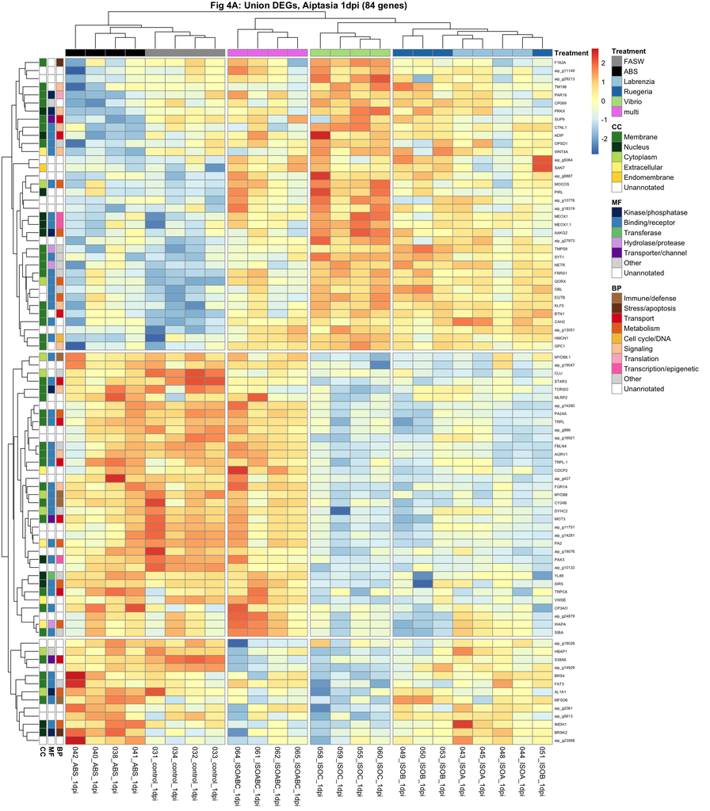

```r
# Helper to build a 4A heatmap with BP + MF + CC row annotations and gene names
make_fig4a <- function(sig_genes, vsd, timepoint_label) {
  mat <- assay(vsd[, vsd$timepoint == timepoint_label])[sig_genes, ]
  mat_z <- t(scale(t(mat)))
  mat_z <- mat_z[complete.cases(mat_z), ]
  cat(timepoint_label, "union DEGs:", length(sig_genes), "->", nrow(mat_z), "plotted\n")

  # Column annotation
  ann_col <- data.frame(
    Treatment = vsd[, vsd$timepoint == timepoint_label]$treatment,
    row.names = colnames(mat_z))

  # Row annotations: BP, MF, CC
  go_cats <- assign_go_cats(rownames(mat_z))
  ann_row <- data.frame(
    BP = go_cats$BP, MF = go_cats$MF, CC = go_cats$CC,
    row.names = rownames(mat_z))

  # Row labels: protein name, fallback to gene_id
  row_lab <- aip_annotate$protein_name[match(rownames(mat_z), aip_annotate$gene_id)]
  row_lab[is.na(row_lab) | row_lab == ""] <- rownames(mat_z)[is.na(row_lab) | row_lab == ""]
  row_lab <- make.unique(row_lab)

  p <- pheatmap(mat_z,
    annotation_col = ann_col,
    annotation_row = ann_row,
    annotation_colors = list(
      Treatment = palette,
      BP = bp_colors[intersect(names(bp_colors), unique(ann_row$BP))],
      MF = mf_colors[intersect(names(mf_colors), unique(ann_row$MF))],
      CC = cc_colors[intersect(names(cc_colors), unique(ann_row$CC))]),
    show_rownames = TRUE,
    labels_row = row_lab,
    fontsize_row = 5.5,
    cutree_rows = 3,
    cutree_cols = 4,
    main = paste0("Fig 4A: Union DEGs, Aiptasia ", timepoint_label,
                  " (", nrow(mat_z), " genes)"),
    silent = TRUE)

  grid::grid.newpage(); grid::grid.draw(p$gtable)

  list(pheatmap_obj = p, mat_z = mat_z, sig_genes = rownames(mat_z))
}

# --- 1dpi ---
sig_1dpi_union <- unique(c(
  rownames(subset(as.data.frame(res_aip_1dpi_ISOA), padj < 0.05)),
  rownames(subset(as.data.frame(res_aip_1dpi_ISOB), padj < 0.05)),
  rownames(subset(as.data.frame(res_aip_1dpi_ISOC), padj < 0.05)),
  rownames(subset(as.data.frame(res_aip_1dpi_ISOABC), padj < 0.05))
))
out_1dpi <- make_fig4a(sig_1dpi_union, vsd_aip, "1dpi")
```

```
## 21dpi union DEGs: 8 -> 8 plotted
```

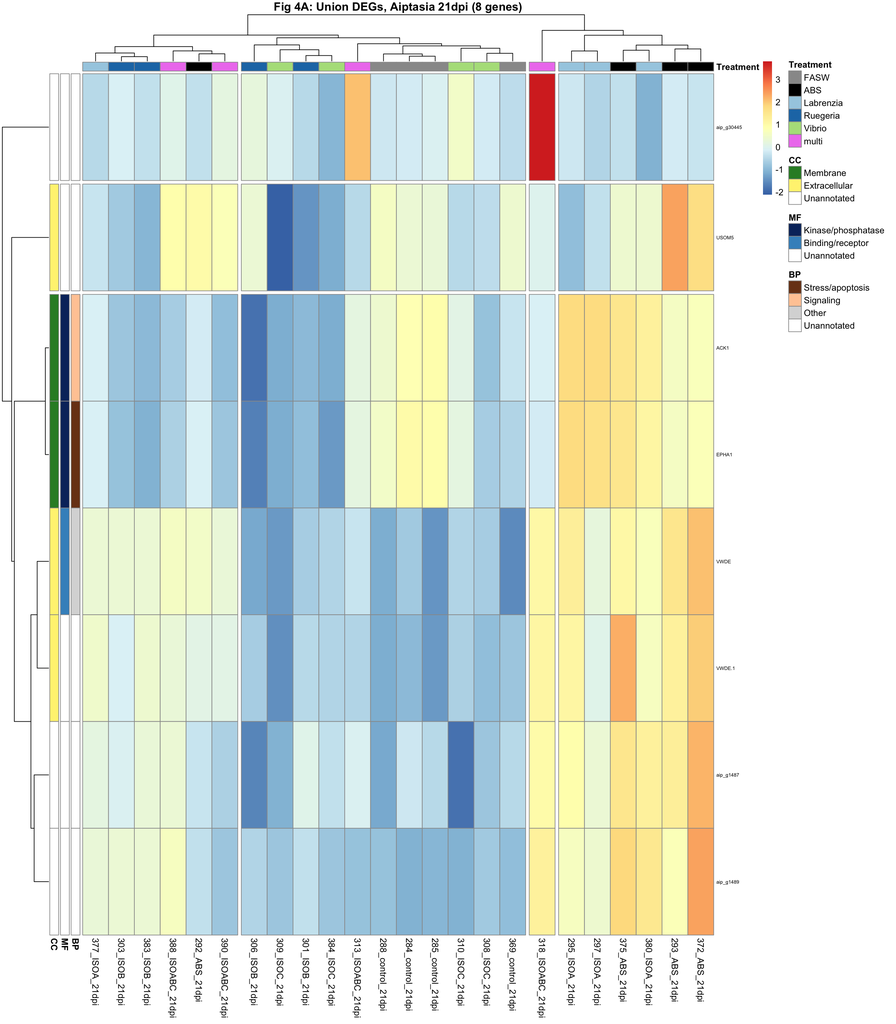

```r
fig4a_1dpi <- out_1dpi$pheatmap_obj

# --- 21dpi ---
sig_21dpi_union <- unique(c(
  rownames(subset(as.data.frame(res_aip_21dpi_ISOA), padj < 0.05)),
  rownames(subset(as.data.frame(res_aip_21dpi_ISOB), padj < 0.05)),
  rownames(subset(as.data.frame(res_aip_21dpi_ISOC), padj < 0.05)),
  rownames(subset(as.data.frame(res_aip_21dpi_ISOABC), padj < 0.05))
))
out_21dpi <- make_fig4a(sig_21dpi_union, vsd_aip, "21dpi")
```

```r
fig4a_21dpi <- out_21dpi$pheatmap_obj
```

### Fig 4A — Full Annotated DEG Tables

```r
fig4a_contrasts_1dpi <- list(
  Labrenzia_vs_ABS = res_aip_1dpi_ISOA,
  Ruegeria_vs_ABS  = res_aip_1dpi_ISOB,
  Vibrio_vs_ABS    = res_aip_1dpi_ISOC,
  multi_vs_ABS     = res_aip_1dpi_ISOABC
)
fig4a_contrasts_21dpi <- list(
  Labrenzia_vs_ABS = res_aip_21dpi_ISOA,
  Ruegeria_vs_ABS  = res_aip_21dpi_ISOB,
  Vibrio_vs_ABS    = res_aip_21dpi_ISOC,
  multi_vs_ABS     = res_aip_21dpi_ISOABC
)

fig4a_table_1dpi  <- build_deg_table(sig_1dpi_union, fig4a_contrasts_1dpi)
fig4a_table_21dpi <- build_deg_table(sig_21dpi_union, fig4a_contrasts_21dpi)

cat("Fig 4A 1dpi:", nrow(fig4a_table_1dpi), "genes\n")
```

```
## Fig 4A 1dpi: 61 genes
```

```r
cat("Fig 4A 21dpi:", nrow(fig4a_table_21dpi), "genes\n")
```

```
## Fig 4A 21dpi: 5 genes
```

```r
write_csv(fig4a_table_1dpi, "../results/Fig4A_DEG_table_1dpi.csv")
write_csv(fig4a_table_21dpi, "../results/Fig4A_DEG_table_21dpi.csv")

# Print a summary: gene counts per BP category
cat("\n--- 1dpi BP category breakdown ---\n")
```

```
##
## --- 1dpi BP category breakdown ---
```

```r
fig4a_table_1dpi %>% dplyr::count(BP_category, sort = TRUE) %>% print()
```

```
## # A tibble: 10 × 2
##    BP_category                  n
##    <chr>                    <int>
##  1 Other                       12
##  2 Metabolism                  10
##  3 Unannotated                 10
##  4 Signaling                    9
##  5 Transport                    9
##  6 Immune/defense               4
##  7 Transcription/epigenetic     3
##  8 Stress/apoptosis             2
##  9 Cell cycle/DNA               1
## 10 Translation                  1
```

```r
cat("\n--- 21dpi BP category breakdown ---\n")
```

```
##
## --- 21dpi BP category breakdown ---
```

```r
fig4a_table_21dpi %>% dplyr::count(BP_category, sort = TRUE) %>% print()
```

```
## # A tibble: 4 × 2
##   BP_category          n
##   <chr>            <int>
## 1 Unannotated          2
## 2 Other                1
## 3 Signaling            1
## 4 Stress/apoptosis     1
```

```r
cat("Full tables saved to ../results/Fig4A_DEG_table_*.csv\n")
```

```
## Full tables saved to ../results/Fig4A_DEG_table_*.csv
```

## 8.9 Fig 5: Single Isolate vs Community — Host Gene Response

Uses single vs community contrasts from Section 8.4. Includes Vibrio panels to test whether community-enriched genes are truly community-specific or driven by Vibrio presence. This is host data (how the host responds differently to single inocula vs the 3-member community).

### Fig 5A-F — Volcano Plots (log2FC vs -log10 padj)

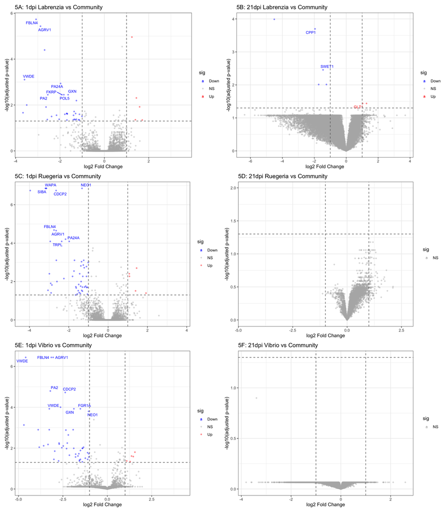

```r
# Reuses plot_volcano() from Section 8.6
# positive log2FC = HIGHER in single inoculation
# negative log2FC = HIGHER in community (multi)
# Red/Up = enriched in single | Blue/Down = enriched in community

p_fig5a <- plot_volcano(res_aip_1dpi_ISOA_vs_ISOABC, aip_annotate,
            "5A: 1dpi Labrenzia vs Community")
p_fig5b <- plot_volcano(res_aip_21dpi_ISOA_vs_ISOABC, aip_annotate,
            "5B: 21dpi Labrenzia vs Community")
p_fig5c <- plot_volcano(res_aip_1dpi_ISOB_vs_ISOABC, aip_annotate,
            "5C: 1dpi Ruegeria vs Community")
p_fig5d <- plot_volcano(res_aip_21dpi_ISOB_vs_ISOABC, aip_annotate,
            "5D: 21dpi Ruegeria vs Community")
p_fig5e_vib <- plot_volcano(res_aip_1dpi_ISOC_vs_ISOABC, aip_annotate,
            "5E: 1dpi Vibrio vs Community")
p_fig5f_vib <- plot_volcano(res_aip_21dpi_ISOC_vs_ISOABC, aip_annotate,
            "5F: 21dpi Vibrio vs Community")

(p_fig5a + p_fig5b) / (p_fig5c + p_fig5d) / (p_fig5e_vib + p_fig5f_vib)
```

### Fig 5 — Gene Function Key

```r
# Collect the top-10-by-padj genes that get labeled on each volcano
fig5_key <- map_dfr(list(
  "5A: 1dpi Lab vs Community"  = res_aip_1dpi_ISOA_vs_ISOABC,
  "5B: 21dpi Lab vs Community" = res_aip_21dpi_ISOA_vs_ISOABC,
  "5C: 1dpi Rue vs Community"  = res_aip_1dpi_ISOB_vs_ISOABC,
  "5D: 21dpi Rue vs Community" = res_aip_21dpi_ISOB_vs_ISOABC,
  "5E: 1dpi Vib vs Community"  = res_aip_1dpi_ISOC_vs_ISOABC,
  "5F: 21dpi Vib vs Community" = res_aip_21dpi_ISOC_vs_ISOABC
), function(res) {
  as.data.frame(res) %>%
    rownames_to_column("gene_id") %>%
    filter(!is.na(padj)) %>%
    mutate(sig = case_when(
      padj < 0.05 & log2FoldChange > 1  ~ "Up (single)",
      padj < 0.05 & log2FoldChange < -1 ~ "Up (community)",
      TRUE ~ "NS")) %>%
    filter(sig != "NS") %>%
    slice_min(padj, n = 10, with_ties = FALSE)
}, .id = "panel") %>%
  left_join(aip_annotate %>%
    select(gene_id, protein_name, Hit_description..SwissProt.,
           any_of(c("GO_BP..SwissProt.", "GO_BP..TrEMBL."))),
    by = "gene_id") %>%
  mutate(
    bp_annot = coalesce(
      if ("GO_BP..SwissProt." %in% names(.)) .[["GO_BP..SwissProt."]] else NA_character_,
      if ("GO_BP..TrEMBL." %in% names(.)) .[["GO_BP..TrEMBL."]] else NA_character_),
    function_summary = case_when(
      !is.na(Hit_description..SwissProt.) & Hit_description..SwissProt. != "" ~
        str_trunc(Hit_description..SwissProt., 60),
      !is.na(bp_annot) & bp_annot != "" ~ str_trunc(bp_annot, 60),
      TRUE ~ "Unknown function")) %>%
  select(panel, gene_id, protein_name, direction = sig,
         log2FoldChange, padj, function_summary) %>%
  distinct(gene_id, panel, .keep_all = TRUE) %>%
  arrange(panel, direction, padj)

write_csv(fig5_key, "../results/Fig5_volcano_gene_key.csv")
cat("Fig 5 gene key:", nrow(fig5_key), "genes saved to ../results/Fig5_volcano_gene_key.csv\n")
```

```
## Fig 5 gene key: 37 genes saved to ../results/Fig5_volcano_gene_key.csv
```

### Fig 5 — Full Annotated DEG Table

```r
fig5_contrasts <- list(
  "1dpi_Labrenzia_vs_Community"  = res_aip_1dpi_ISOA_vs_ISOABC,
  "21dpi_Labrenzia_vs_Community" = res_aip_21dpi_ISOA_vs_ISOABC,
  "1dpi_Ruegeria_vs_Community"   = res_aip_1dpi_ISOB_vs_ISOABC,
  "21dpi_Ruegeria_vs_Community"  = res_aip_21dpi_ISOB_vs_ISOABC,
  "1dpi_Vibrio_vs_Community"     = res_aip_1dpi_ISOC_vs_ISOABC,
  "21dpi_Vibrio_vs_Community"    = res_aip_21dpi_ISOC_vs_ISOABC
)

fig5_all_sig <- unique(unlist(lapply(fig5_contrasts, function(res) {
  rownames(subset(as.data.frame(res), padj < 0.05))
})))
cat("Fig 5 total unique DEGs:", length(fig5_all_sig), "\n")
```

```
## Fig 5 total unique DEGs: 140
```

```r
if (length(fig5_all_sig) > 0) {
  fig5_table <- build_deg_table(fig5_all_sig, fig5_contrasts)
  write_csv(fig5_table, "../results/Fig5_DEG_table_single_vs_community.csv")

  cat("\n--- Fig 5 BP category breakdown ---\n")
  fig5_table %>% dplyr::count(BP_category, sort = TRUE) %>% print()

  cat("Full table saved to ../results/Fig5_DEG_table_single_vs_community.csv\n")
} else {
  cat("No significant DEGs in any Fig 5 contrast\n")
}
```

```
##
## --- Fig 5 BP category breakdown ---
## # A tibble: 9 × 2
##   BP_category                  n
##   <chr>                    <int>
## 1 Metabolism                  17
## 2 Immune/defense              16
## 3 Other                       16
## 4 Transport                   13
## 5 Unannotated                 13
## 6 Signaling                   12
## 7 Stress/apoptosis             7
## 8 Cell cycle/DNA               3
## 9 Transcription/epigenetic     3
## Full table saved to ../results/Fig5_DEG_table_single_vs_community.csv
```

## 8.10 Pathway Composition — DEG Counts by GO Category

Stacked bar charts showing the breakdown of up- and downregulated DEGs (padj < 0.05) into GO Biological Process, Molecular Function, and Cellular Component categories. Positive bars = upregulated vs ABS; negative bars = downregulated vs ABS.

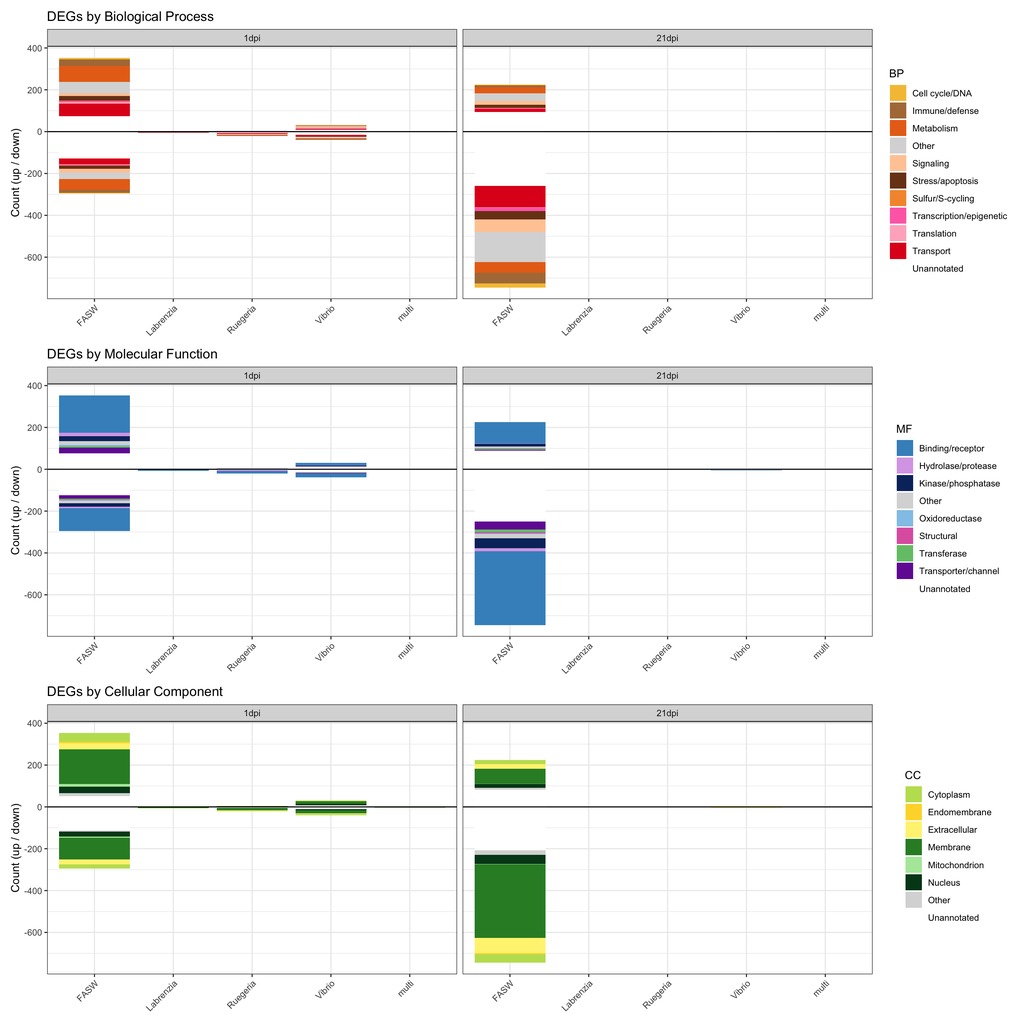

```r
# Collect all DEGs from treatment vs ABS contrasts with GO categories
deg_lfc_pre <- map_dfr(names(all_host_contrasts_vol), function(cn) {
  as.data.frame(all_host_contrasts_vol[[cn]]) %>%
    rownames_to_column("gene_id") %>%
    filter(!is.na(padj), padj < 0.05) %>%
    mutate(contrast  = cn,
           direction = if_else(log2FoldChange > 0, "Up", "Down", missing = "Down"),
           timepoint = str_extract(cn, "^\\d+dpi"),
           treatment = str_extract(cn, "(?<=dpi_)[^_]+(?=_vs)"))
})

go_cats_all <- assign_go_cats(unique(deg_lfc_pre$gene_id))
deg_lfc_cats <- deg_lfc_pre %>%
  left_join(go_cats_all, by = "gene_id") %>%
  mutate(BP = as.character(BP),
         MF = as.character(MF),
         CC = as.character(CC),
         treatment = factor(treatment, levels = c("FASW", "ABS", "Labrenzia", "Ruegeria", "Vibrio", "multi")),
         timepoint = factor(timepoint, levels = c("1dpi", "21dpi")))

# BP stacked bar
plot_pathway_bp <- deg_lfc_cats %>%
  dplyr::count(treatment, timepoint, direction, BP) %>%
  mutate(n_signed = ifelse(direction == "Down", -n, n)) %>%
  ggplot(aes(x = treatment, y = n_signed, fill = BP)) +
  geom_col() +
  geom_hline(yintercept = 0, linewidth = 0.5) +
  scale_fill_manual(values = bp_colors) +
  facet_wrap(~ timepoint) +
  theme_bw() +
  theme(axis.text.x = element_text(angle = 45, hjust = 1)) +
  labs(title = "DEGs by Biological Process", y = "Count (up / down)", x = NULL)

# MF stacked bar
plot_pathway_mf <- deg_lfc_cats %>%
  dplyr::count(treatment, timepoint, direction, MF) %>%
  mutate(n_signed = ifelse(direction == "Down", -n, n)) %>%
  ggplot(aes(x = treatment, y = n_signed, fill = MF)) +
  geom_col() +
  geom_hline(yintercept = 0, linewidth = 0.5) +
  scale_fill_manual(values = mf_colors) +
  facet_wrap(~ timepoint) +
  theme_bw() +
  theme(axis.text.x = element_text(angle = 45, hjust = 1)) +
  labs(title = "DEGs by Molecular Function", y = "Count (up / down)", x = NULL)

# CC stacked bar
plot_pathway_cc <- deg_lfc_cats %>%
  dplyr::count(treatment, timepoint, direction, CC) %>%
  mutate(n_signed = ifelse(direction == "Down", -n, n)) %>%
  ggplot(aes(x = treatment, y = n_signed, fill = CC)) +
  geom_col() +
  geom_hline(yintercept = 0, linewidth = 0.5) +
  scale_fill_manual(values = cc_colors) +
  facet_wrap(~ timepoint) +
  theme_bw() +
  theme(axis.text.x = element_text(angle = 45, hjust = 1)) +
  labs(title = "DEGs by Cellular Component", y = "Count (up / down)", x = NULL)

plot_pathway_bp / plot_pathway_mf / plot_pathway_cc
```

```r
ggsave("../results/pathway_composition_BP.pdf", plot_pathway_bp, width = 12, height = 5)
ggsave("../results/pathway_composition_MF.pdf", plot_pathway_mf, width = 12, height = 5)
ggsave("../results/pathway_composition_CC.pdf", plot_pathway_cc, width = 12, height = 5)
```

## 8.11 Log2FC Boxplots by GO Category

Distribution of log2 fold-change values across GO categories, showing the direction and magnitude of expression change per functional group. Each box = all DEGs in that category; fill = treatment; facets = timepoint.

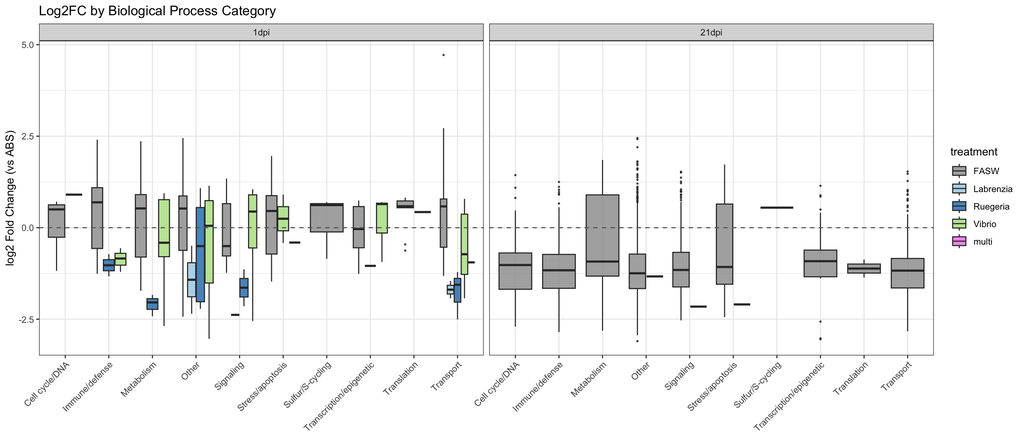

```r
plot_lfc_bp <- deg_lfc_cats %>%
  filter(BP != "Unannotated") %>%
  ggplot(aes(x = BP, y = log2FoldChange, fill = treatment)) +
  geom_boxplot(outlier.size = 0.4, position = position_dodge(0.8), alpha = 0.8) +
  geom_hline(yintercept = 0, linetype = "dashed", color = "gray40") +
  facet_wrap(~ timepoint) +
  scale_fill_manual(values = palette) +
  theme_bw() +
  theme(axis.text.x = element_text(angle = 45, hjust = 1)) +
  labs(title = "Log2FC by Biological Process Category",
       y = "log2 Fold Change (vs ABS)", x = NULL)
plot_lfc_bp
```

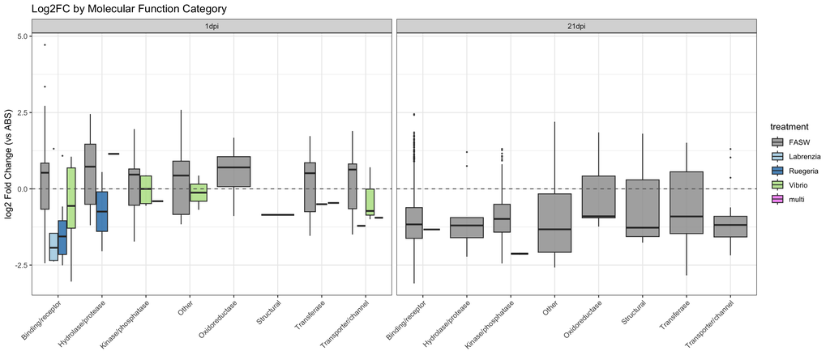

```r
plot_lfc_mf <- deg_lfc_cats %>%
  filter(MF != "Unannotated") %>%
  ggplot(aes(x = MF, y = log2FoldChange, fill = treatment)) +
  geom_boxplot(outlier.size = 0.4, position = position_dodge(0.8), alpha = 0.8) +
  geom_hline(yintercept = 0, linetype = "dashed", color = "gray40") +
  facet_wrap(~ timepoint) +
  scale_fill_manual(values = palette) +
  theme_bw() +
  theme(axis.text.x = element_text(angle = 45, hjust = 1)) +
  labs(title = "Log2FC by Molecular Function Category",
       y = "log2 Fold Change (vs ABS)", x = NULL)
plot_lfc_mf
```

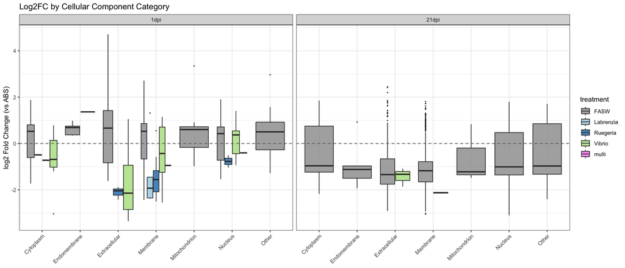

```r
plot_lfc_cc <- deg_lfc_cats %>%
  filter(CC != "Unannotated") %>%
  ggplot(aes(x = CC, y = log2FoldChange, fill = treatment)) +
  geom_boxplot(outlier.size = 0.4, position = position_dodge(0.8), alpha = 0.8) +
  geom_hline(yintercept = 0, linetype = "dashed", color = "gray40") +
  facet_wrap(~ timepoint) +
  scale_fill_manual(values = palette) +
  theme_bw() +
  theme(axis.text.x = element_text(angle = 45, hjust = 1)) +
  labs(title = "Log2FC by Cellular Component Category",
       y = "log2 Fold Change (vs ABS)", x = NULL)
plot_lfc_cc
```

```r
ggsave("../results/lfc_boxplot_BP.pdf", plot_lfc_bp, width = 14, height = 6)
ggsave("../results/lfc_boxplot_MF.pdf", plot_lfc_mf, width = 14, height = 6)
ggsave("../results/lfc_boxplot_CC.pdf", plot_lfc_cc, width = 14, height = 6)
```

# 9. DESeq2 Analysis — Symbiont (*Symbiodiniaceae*)

Same workflow as Section 8, now applied to algal symbiont genes

```r
dds_sym <- DESeqDataSetFromMatrix(
  countData = counts_sym,
  colData = colData,
  design = ~ timepoint + treatment)

cat(nrow(dds_sym), "genes before filtering\n")
```

```
## 43403 genes before filtering
```

```r
keep <- rowSums(counts(dds_sym) >= 10) >= 4
dds_sym <- dds_sym[keep, ]
cat(nrow(dds_sym), "genes after filtering\n")
```

```
## 12921 genes after filtering
```

```r
dds_sym <- DESeq(dds_sym)
```

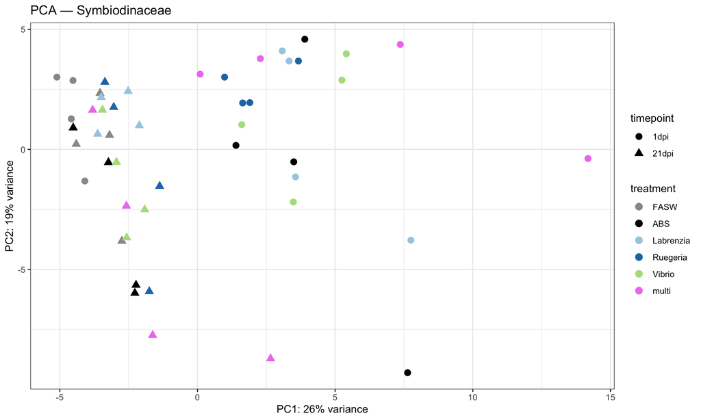

```r
vsd_sym <- vst(dds_sym, blind = TRUE)

sym_pca <- plotPCA(vsd_sym, intgroup = c("treatment", "timepoint"), returnData = TRUE)
percent_var <- round(100 * attr(sym_pca, "percentVar"))

p <- ggplot(sym_pca, aes(x = PC1, y = PC2, color = treatment, shape = timepoint)) +
  geom_point(size = 3) +
  scale_color_manual(values = palette) +
  theme_bw() +
  labs(x = paste0("PC1: ", percent_var[1], "% variance"),
       y = paste0("PC2: ", percent_var[2], "% variance"),
       title = "PCA — Symbiodinaceae")
p
```

```r
ggsave("../results/pca_symbiont_all.pdf", p, width = 7, height = 5)
# Symbiont expression affected by ABS at 1dpi; by 21dpi returns toward control
```

```r
# 1dpi
dds_sym_1dpi <- dds_sym[, dds_sym$timepoint == "1dpi"]
dds_sym_1dpi$timepoint <- droplevels(dds_sym_1dpi$timepoint)
design(dds_sym_1dpi) <- ~ treatment
dds_sym_1dpi <- DESeq(dds_sym_1dpi)

res_sym_1dpi_control <- results(dds_sym_1dpi, contrast = c("treatment", "FASW", "ABS"))
res_sym_1dpi_ISOA    <- results(dds_sym_1dpi, contrast = c("treatment", "Labrenzia", "ABS"))
res_sym_1dpi_ISOB    <- results(dds_sym_1dpi, contrast = c("treatment", "Ruegeria", "ABS"))
res_sym_1dpi_ISOC    <- results(dds_sym_1dpi, contrast = c("treatment", "Vibrio", "ABS"))
res_sym_1dpi_ISOABC  <- results(dds_sym_1dpi, contrast = c("treatment", "multi", "ABS"))

# 21dpi
dds_sym_21dpi <- dds_sym[, dds_sym$timepoint == "21dpi"]
dds_sym_21dpi$timepoint <- droplevels(dds_sym_21dpi$timepoint)
design(dds_sym_21dpi) <- ~ treatment
dds_sym_21dpi <- DESeq(dds_sym_21dpi)

res_sym_21dpi_control <- results(dds_sym_21dpi, contrast = c("treatment", "FASW", "ABS"))
res_sym_21dpi_ISOA    <- results(dds_sym_21dpi, contrast = c("treatment", "Labrenzia", "ABS"))
res_sym_21dpi_ISOB    <- results(dds_sym_21dpi, contrast = c("treatment", "Ruegeria", "ABS"))
res_sym_21dpi_ISOC    <- results(dds_sym_21dpi, contrast = c("treatment", "Vibrio", "ABS"))
res_sym_21dpi_ISOABC  <- results(dds_sym_21dpi, contrast = c("treatment", "multi", "ABS"))
```

```r
deg_summary_sym <- bind_rows(
  summarize_degs(res_sym_1dpi_control) %>% mutate(timepoint = "1dpi",  contrast = "FASW_vs_ABS"),
  summarize_degs(res_sym_1dpi_ISOA)    %>% mutate(timepoint = "1dpi",  contrast = "Labrenzia_vs_ABS"),
  summarize_degs(res_sym_1dpi_ISOB)    %>% mutate(timepoint = "1dpi",  contrast = "Ruegeria_vs_ABS"),
  summarize_degs(res_sym_1dpi_ISOC)    %>% mutate(timepoint = "1dpi",  contrast = "Vibrio_vs_ABS"),
  summarize_degs(res_sym_1dpi_ISOABC)  %>% mutate(timepoint = "1dpi",  contrast = "multi_vs_ABS"),
  summarize_degs(res_sym_21dpi_control) %>% mutate(timepoint = "21dpi", contrast = "FASW_vs_ABS"),
  summarize_degs(res_sym_21dpi_ISOA)    %>% mutate(timepoint = "21dpi", contrast = "Labrenzia_vs_ABS"),
  summarize_degs(res_sym_21dpi_ISOB)    %>% mutate(timepoint = "21dpi", contrast = "Ruegeria_vs_ABS"),
  summarize_degs(res_sym_21dpi_ISOC)    %>% mutate(timepoint = "21dpi", contrast = "Vibrio_vs_ABS"),
  summarize_degs(res_sym_21dpi_ISOABC)  %>% mutate(timepoint = "21dpi", contrast = "multi_vs_ABS")
) %>% select(timepoint, contrast, up, down, total)

deg_summary_sym
```

```
##    timepoint         contrast up down total
## 1       1dpi      FASW_vs_ABS 85  126   211
## 2       1dpi Labrenzia_vs_ABS  0    0     0
## 3       1dpi  Ruegeria_vs_ABS  0    0     0
## 4       1dpi    Vibrio_vs_ABS  1    1     2
## 5       1dpi     multi_vs_ABS  6    2     8
## 6      21dpi      FASW_vs_ABS  3    1     4
## 7      21dpi Labrenzia_vs_ABS  0    0     0
## 8      21dpi  Ruegeria_vs_ABS  0    0     0
## 9      21dpi    Vibrio_vs_ABS  0    0     0
## 10     21dpi     multi_vs_ABS  0    0     0
```

```r
# ABS treatment creates an acute gene expression change in the algal symbiont, response fades by 21dpi. Single inoculations have little influence on algal symbiont gene expression but in multi inoculation there is some influence (6 up and 2 down regulated genes)
```

```r
# Export symbiont DEGs with annotations from parsed GTF
export_degs_sym <- function(res, annotation, filename) {
  df <- as.data.frame(res) %>%
    rownames_to_column("gene_id") %>%
    filter(padj < 0.05) %>%
    left_join(annotation, by = "gene_id") %>%
    arrange(padj)
  write.csv(df, file = filename, row.names = FALSE)
  return(df)
}

deg_sym_1dpi_control <- export_degs_sym(res_sym_1dpi_control, annot_sym, "../results/DEG_sym_1dpi_control_vs_ABS.csv")
deg_sym_1dpi_ISOA    <- export_degs_sym(res_sym_1dpi_ISOA,    annot_sym, "../results/DEG_sym_1dpi_ISOA_vs_ABS.csv")
deg_sym_1dpi_ISOB    <- export_degs_sym(res_sym_1dpi_ISOB,    annot_sym, "../results/DEG_sym_1dpi_ISOB_vs_ABS.csv")
deg_sym_1dpi_ISOC    <- export_degs_sym(res_sym_1dpi_ISOC,    annot_sym, "../results/DEG_sym_1dpi_ISOC_vs_ABS.csv")
deg_sym_1dpi_ISOABC  <- export_degs_sym(res_sym_1dpi_ISOABC,  annot_sym, "../results/DEG_sym_1dpi_ISOABC_vs_ABS.csv")

deg_sym_21dpi_control <- export_degs_sym(res_sym_21dpi_control, annot_sym, "../results/DEG_sym_21dpi_control_vs_ABS.csv")
deg_sym_21dpi_ISOA    <- export_degs_sym(res_sym_21dpi_ISOA,    annot_sym, "../results/DEG_sym_21dpi_ISOA_vs_ABS.csv")
deg_sym_21dpi_ISOB    <- export_degs_sym(res_sym_21dpi_ISOB,    annot_sym, "../results/DEG_sym_21dpi_ISOB_vs_ABS.csv")
deg_sym_21dpi_ISOC    <- export_degs_sym(res_sym_21dpi_ISOC,    annot_sym, "../results/DEG_sym_21dpi_ISOC_vs_ABS.csv")
deg_sym_21dpi_ISOABC  <- export_degs_sym(res_sym_21dpi_ISOABC,  annot_sym, "../results/DEG_sym_21dpi_ISOABC_vs_ABS.csv")

saveRDS(dds_sym, "../results/dds_sym.rds")
saveRDS(dds_sym_1dpi, "../results/dds_sym_1dpi.rds")
saveRDS(dds_sym_21dpi, "../results/dds_sym_21dpi.rds")
```

# 10. Bacterial Gene Expression (*Labrenzia*, *Ruegeria*, *Vibrio*)

## 10.1 DESeq Feasibility Assessment

```r
relevant_treatments <- list(
  lab = c("ABS", "Labrenzia", "multi"),
  rue = c("ABS", "Ruegeria", "multi"),
  vib = c("ABS", "Vibrio", "multi")
)

bacterial_counts <- list(lab = counts_lab, rue = counts_rue, vib = counts_vib)

bact_feasibility <- map_dfr(names(bacterial_counts), function(org) {
  mat <- bacterial_counts[[org]]
  rel_samples <- rownames(colData)[colData$treatment %in% relevant_treatments[[org]]]
  mat_rel <- mat[, rel_samples]

  data.frame(
    organism = org,
    relevant_samples = ncol(mat_rel),
    median_library_size = median(colSums(mat_rel)),
    genes_detected = sum(rowSums(mat_rel) > 0),
    genes_passing_filter = sum(rowSums(mat_rel >= 5) >= 2)
  )
})

bact_feasibility
```

```
##   organism relevant_samples median_library_size genes_detected
## 1      lab               24               285.0           3126
## 2      rue               24               108.5           1765
## 3      vib               24                47.0           2243
##   genes_passing_filter
## 1                   34
## 2                   45
## 3                  159
```

```r
# All three fail feasibility (need >10k median library, >100 genes passing filter)
# Labrenzia: 285 reads, 34 genes; Ruegeria: 108 reads, 45 genes; Vibrio: 47 reads, 159 genes
# Library sizes ~100x too low for DESeq2 dispersion estimation
```

## 10.2 dmdA and dddL Search

Search bacterial annotations for DMSP-cycling genes: `dmdA` (DMSP demethylase) and `dddL` (DMSP lyase). Also performs a broader sulfur/DMSP product search as a fallback. TPM values are plotted across all treatments and timepoints for any hits found.

```r
# Targeted search: gene name or product description
sulfur_hits <- annot_bact %>%
  filter(
    grepl("dmdA|dddL", gene_name, ignore.case = TRUE) |
    grepl("dmdA|dddL|DMSP demethylase|DMSP lyase|dimethylsulfoniopropionate lyase|dimethylsulfoniopropionate demethylase",
          product, ignore.case = TRUE)
  )

cat("Targeted dmdA/dddL hits:\n")
```

```
## Targeted dmdA/dddL hits:
```

```r
print(sulfur_hits %>% select(organism, gene_id, gene_name, product))
```

```
##    organism          gene_id gene_name                                product
## 1 Labrenzia lab_AODPDA_04350      <NA> Dimethlysulfonioproprionate lyase DddL
## 2  Ruegeria rue_LDIBIJ_06965      dmdA dimethylsulfoniopropionate demethylase
```

```r
# Broader DMSP/sulfur catalog
sulfur_broad <- annot_bact %>%
  filter(grepl("sulfur|DMSP|dimethyl|methanethiol|\\bDMS\\b|thiosulfate|sulfo|methionine sulfoxide",
               product, ignore.case = TRUE)) %>%
  select(organism, gene_id, gene_name, product)

cat("\nBroader sulfur/DMSP gene catalog:\n")
```

```
##
## Broader sulfur/DMSP gene catalog:
```

```r
print(sulfur_broad)
```

```
##      organism          gene_id   gene_name
## 1   Labrenzia lab_AODPDA_00255        tauB
## 2   Labrenzia lab_AODPDA_00705        <NA>
## 3   Labrenzia lab_AODPDA_01040        <NA>
## 4   Labrenzia lab_AODPDA_02600        soxB
## 5   Labrenzia lab_AODPDA_02605        soxA
## 6   Labrenzia lab_AODPDA_02610        soxZ
## 7   Labrenzia lab_AODPDA_02615        soxY
## 8   Labrenzia lab_AODPDA_02620        soxX
## 9   Labrenzia lab_AODPDA_03095        csdA
## 10  Labrenzia lab_AODPDA_03345        petA
## 11  Labrenzia lab_AODPDA_03375        bluB
## 12  Labrenzia lab_AODPDA_04110        msrP
## 13  Labrenzia lab_AODPDA_04350        <NA>
## 14  Labrenzia lab_AODPDA_05180        <NA>
```

[output cut: 257 more lines]

[figure not shown]

```r
# Combine and plot TPM for any hits present in count matrix
sulfur_ids <- unique(c(sulfur_hits$gene_id, sulfur_broad$gene_id))
sulfur_ids <- sulfur_ids[sulfur_ids %in% rownames(tpm_matrix)]

if (length(sulfur_ids) > 0) {
  sulfur_annot <- bind_rows(sulfur_hits, sulfur_broad %>%
    left_join(annot_bact %>% select(gene_id, gene_name, product, organism), by = c("gene_id","gene_name","product","organism"))) %>%
    distinct(gene_id, .keep_all = TRUE) %>%
    mutate(gene_label = case_when(
      !is.na(gene_name) & gene_name != "" ~ paste0(gene_name, " (", organism, ")"),
      TRUE ~ paste0(str_trunc(product, 25), " (", organism, ")")
    ))

  tpm_matrix[sulfur_ids, , drop = FALSE] %>%
    as.data.frame() %>%
    rownames_to_column("gene_id") %>%
    pivot_longer(-gene_id, names_to = "sample", values_to = "TPM") %>%
    left_join(metadata, by = "sample") %>%
    left_join(sulfur_annot %>% select(gene_id, gene_label), by = "gene_id") %>%
    mutate(TPM_plot = pmax(TPM, 0.001)) %>%
    ggplot(aes(x = treatment, y = TPM_plot, color = treatment)) +
    geom_jitter(width = 0.2, size = 2, alpha = 0.8) +
    geom_boxplot(outlier.shape = NA, alpha = 0.2, color = "black") +
    facet_grid(gene_label ~ timepoint, scales = "free_y") +
    scale_color_manual(values = palette) +
    scale_y_log10() +
    theme_bw() +
    theme(axis.text.x = element_text(angle = 45, hjust = 1),
          strip.text.y = element_text(size = 7),
          legend.position = "none") +
    labs(title = "dmdA / dddL and Related Sulfur Cycling Genes: TPM",
         y = "TPM (log10 scale)", x = NULL)
} else {
  cat("No dmdA/dddL or related sulfur cycling genes found in count matrix.\n")
}
```

# 11. Save Outputs and Session Info

## Save Publication Figures

```r
# Fig 4A — bicluster heatmaps
pdf("../results/Fig4A_bicluster_1dpi.pdf", width = 12, height = 10)
fig4a_1dpi
dev.off()
```

```r
pdf("../results/Fig4A_bicluster_21dpi.pdf", width = 12, height = 10)
fig4a_21dpi
dev.off()
```

```r
# Fig 5A-F — volcano panel
fig5_volcano_panel <- (p_fig5a + p_fig5b) / (p_fig5c + p_fig5d) / (p_fig5e_vib + p_fig5f_vib)
ggsave("../results/Fig5_volcanoes_single_vs_community.pdf",
       fig5_volcano_panel, width = 14, height = 16)
ggsave("../results/Fig5_volcanoes_single_vs_community.png",
       fig5_volcano_panel, width = 14, height = 16, dpi = 300)

# Save annotation tables for downstream use
write.csv(annot_bact, "../results/annotation_bacteria.csv", row.names = FALSE)
write.csv(annot_sym, "../results/annotation_symbiodiniaceae.csv", row.names = FALSE)
```